# Genome-wide LCL co-accessibility: top ten pairs

Crystal Shan

# Co-accessibility analysis

This analysis looks for co-accessibility CREs in pooled 31 sample LCL data

## Analysis overview

1. Merge FIRE peaks from all samples -> union FIRE peaks
2. Define CREs universe by overlap with the union FIRE peaks
3. Link CRE to genes -> build 10kb window around TSS for each canonical TSS (MANE Select: The gold-standard joint NCBI/EMBL-EBI default transcript for human protein-coding genes)
4. Extract each sample’s aligned blocks from FIRE CRAM -> aligned blocks
5. Build candidate CRE pairs, the two CREs must share the 10kb TSS window and 500 < gap < 20,000 bp
6. Filter for reads that fully cover both CREs
7. Identify which reads are accessible at each CRE -> a CRE is accessible if it 50% overlaps with a FIRE element, and restrict this to the aligned blocks
8. Build 2x2 table for fisher test on reads fully spanning both CREs: neither, CRE1 only, CRE2 only, both, and sum the counts across all samples
9. Fisher test + 1 pseudocount on row counts from 2x2 table, and calculate OR
10. Coverage filter: a pair is tested (BH correction, FDR) only if at least 20 fibers span both CREs, summed across samples (chrX in the female-chrX-removed section: male samples only); pairs below this keep their p-value but have FDR = NA

# Setup

```r
suppressPackageStartupMessages({
  library(data.table)
  library(ggplot2)
  library(patchwork)
  library(dplyr)
})
source(file.path(params$code_root, "parsing_functions", "parsing_footprints_functions.r"), local = TRUE)
source(file.path(params$code_root, "parsing_functions", "stats_testing_functions.r"), local = TRUE)
source(file.path(params$code_root, "parsing_functions", "plotting_functions.r"), local = TRUE)
options(scipen = 999)
```

```r
root <- params$root
coaccess_dir <- file.path(root, "coaccess")
universe_dir <- file.path(root, "universe")
out_dir <- file.path(coaccess_dir, "all_chr")
table_dir <- file.path(out_dir, "tables")
plot_dir <- file.path(out_dir, "plots")
fire_overlap_fraction <- 0.5
fdr_cutoff <- 0.05
paths <- list(root = root, fire_root = params$fire_root,
              ft_root = params$fire_root, tf_root = params$tf_root,
              tabix_bin = params$tabix, fire_ver = "v0.1")
for (d in c(table_dir, plot_dir)) dir.create(d, recursive = TRUE, showWarnings = FALSE)
stopifnot(params$locus_flank_bp >= 0)
```

# Input data

read sample metadata: `/project/spott/1_Shared_projects/LCL_Fiber_seq/Data/LCL_sample_metatable_merged_samples_31samples.csv`

sample manifest - containing the file path to FIRE CRAM, element and peaks: `/project/spott/cshan/fiber-seq/LCL_project/co-accessibility/universe/sample_manifest.tsv`

```r
sample_meta <- fread(params$sample_sheet)
manifest <- fread(file.path(universe_dir, "sample_manifest.tsv"))
stopifnot(all(c("sample_name", "cell_line") %in% names(sample_meta)),
          all(c("sample_name", "donor") %in% names(manifest)),
          nrow(sample_meta) == 31L, nrow(manifest) == 31L,
          !anyDuplicated(sample_meta$sample_name), !anyDuplicated(manifest$sample_name),
          setequal(sample_meta$sample_name, manifest$sample_name))
sample_meta[, donor := as.character(cell_line)]
samples <- as.character(manifest$sample_name)
stopifnot(identical(as.character(manifest$donor),
                    sample_meta$donor[match(samples, sample_meta$sample_name)]))
head(sample_meta[, .(sample_name, donor)], 5)
```

```
##          sample_name   donor
##               <char>  <char>
## 1:  AL6_bc2162_19093 NA19093
## 2:  AL8_bc2170_19151 NA19151
## 3: AL10_bc2178_19130 NA19130
## 4: AL16_bc2114_18508 NA18508
## 5: AL18_bc2130_18504 NA18504
```

Reads sample_manifest.tsv, and check it has 31 unique sample names

- saved co-accessibility results came from the same inputs as the cCRE universe. It compares the sample manifest saved with the finished counting run against the universe’s manifest, checking the sample names, donors, and file paths

```r
run_manifest <- fread(file.path(coaccess_dir, "sample_manifest.tsv"))
provenance_columns <- c("sample_name", "donor", "fire_dir", "cram_path", "elements_path", "spans_path")
stopifnot(all(provenance_columns %in% names(run_manifest)),
          all(provenance_columns %in% names(manifest)),
          nrow(run_manifest) == 31L, !anyDuplicated(run_manifest$sample_name),
          setequal(run_manifest$sample_name, samples))
run_manifest <- run_manifest[match(samples, sample_name)]
for (column in provenance_columns)
  if (!identical(as.character(run_manifest[[column]]), as.character(manifest[[column]])))
    stop("Universe and completed-run manifests differ in ", column, "; rerun the analysis.")
same_paths <- function(a, b)
  identical(normalizePath(a, mustWork = FALSE), normalizePath(b, mustWork = FALSE))
stopifnot("blocks_path" %in% names(run_manifest),
  same_paths(run_manifest$blocks_path,
  file.path(root, samples, paste0(samples, ".aligned_blocks.bed.gz"))),
  same_paths(run_manifest$elements_path,
    file.path(paths$fire_root, samples, "additional-outputs-v0.1", "fire-peaks",
              paste0(samples, "-v0.1-fire-elements.bed.gz"))))
```

Read Co-accessible CRE pairs

```r
pairs_file <- file.path(coaccess_dir, "LCL_coaccess_pairs.tsv.gz")
pairs_dt <- fread(pairs_file)
cat(nrow(pairs_dt), "unique pairs loaded;", sum(!is.na(pairs_dt$fdr)), "tested (>= 20 spanning fibers).\n")
```

```
## 248879 unique pairs loaded; 233525 tested (>= 20 spanning fibers).
```

```r
head(pairs_dt)
```

```
##                                                               CRE_pair
##                                                                 <char>
## 1:       EH38D4327590.EH38E2776544.pELS-EH38D4327591.EH38E2776545.dELS
## 2:        EH38D4327591.EH38E2776545.dELS-EH38D4327608.EH38E2776554.PLS
## 3:        EH38D4327591.EH38E2776545.dELS-EH38D4327609.EH38E2776555.PLS
## 4:       EH38D6144737.EH38E3951325.dELS-EH38D2115375.EH38E1310193.dELS
## 5: EH38D6144737.EH38E3951325.dELS-EH38D4327653.EH38E2776581.CA-H3K4me3
## 6: EH38D2115375.EH38E1310193.dELS-EH38D4327653.EH38E2776581.CA-H3K4me3
##                              CRE1                                 CRE2  dist
##                            <char>                               <char> <int>
## 1: EH38D4327590.EH38E2776544.pELS       EH38D4327591.EH38E2776545.dELS  9665
## 2: EH38D4327591.EH38E2776545.dELS        EH38D4327608.EH38E2776554.PLS 11967
## 3: EH38D4327591.EH38E2776545.dELS        EH38D4327609.EH38E2776555.PLS 12490
## 4: EH38D6144737.EH38E3951325.dELS       EH38D2115375.EH38E1310193.dELS  7504
## 5: EH38D6144737.EH38E3951325.dELS EH38D4327653.EH38E2776581.CA-H3K4me3 11439
```

[output cut: 65 more lines]

CRE annotations: accessible CREs that overlap with a FIRE peak

```r
cre_universe <- fread(file.path(universe_dir, "cre_universe.bed"), header = FALSE,
  col.names = c("chrom", "start", "end", "CRE_ID", "CRE_label"))

head(cre_universe)
```

```
##     chrom  start    end                               CRE_ID  CRE_label
##    <char>  <int>  <int>                               <char>     <char>
## 1:   chr1  29320  29517         EH38D6144703.EH38E3951274.CA         CA
## 2:   chr1 104896 105048    EH38D4327509.EH38E2776520.CA-CTCF    CA-CTCF
## 3:   chr1 181014 181237 EH38D4327524.EH38E2776523.CA-H3K4me3 CA-H3K4me3
## 4:   chr1 181289 181639 EH38D4327525.EH38E2776524.CA-H3K4me3 CA-H3K4me3
## 5:   chr1 267925 268171    EH38D4327544.EH38E2776528.CA-CTCF    CA-CTCF
## 6:   chr1 778570 778919        EH38D4327580.EH38E2776539.PLS        PLS
```

### Top ten co-accessible pairs

1. Pick pairs with fdr < 0.05
2. OR > 1
3. observed co-accessiblility > number expected under independence

smallest FDR -> largest OR -> highest # of spanning molecules -> pair ID alphabetical order

```r
eligible <- pairs_dt[!is.na(fdr) & fdr < fdr_cutoff & !is.na(OR) & OR > 1 &
                       co_access > expected_co_access]

# smallest FDR -> largest OR -> highest # of spanning molecules -> pair ID alphabetical order
setorderv(eligible, c("fdr", "OR", "n_shared_reads", "CRE_pair"), c(1L, -1L, -1L, 1L))
selected <- head(eligible, 10L)

# define plotting window for each pair: start = CRE1 - 1000, end = CRE2 + 1000
selected[, `:=`(
  region_start = pmax(0L, pmin(cre1_start, cre2_start) - as.integer(params$locus_flank_bp)),
  region_end = pmax(cre1_end, cre2_end) + as.integer(params$locus_flank_bp))]
selected[, pair_id := sprintf("top%d_%s_%d_%d", seq_len(.N), chrom, region_start, region_end)]
fwrite(selected, file.path(coaccess_dir, "LCL_top10_pairs.tsv"), sep = "\t")
cat(nrow(eligible), "pairs pass the positive-association criteria; selected",
    nrow(selected), "for plotting.\n")
```

```
## 3332 pairs pass the positive-association criteria; selected 10 for plotting.
```

```r
if (nrow(selected) < 10L)
  cat("Fewer than ten pairs qualify; only qualifying pairs will be shown.\n")

top10_coaccess_df <- selected[, .(pair_id, gene_names, CRE_pair, dist, n_shared_reads,
  co_access, expected_co_access, observed_expected_ratio, OR, fdr, fdr_raw)]

print(top10_coaccess_df)
```

```
##                            pair_id           gene_names
##                             <char>               <char>
##  1:    top1_chrX_77894378_77900509          COX7B;MAGT1
##  2:  top2_chrX_135519482_135523030    INTS6L;INTS6L-AS1
##  3:  top3_chrX_149502503_149506532                  IDS
##  4:    top4_chrX_73850175_73853902 ENSG00000278039;XIST
##  5:   top5_chr14_57492840_57496756              CCDC198
##  6:  top6_chrX_123959245_123964346      STAG2;STAG2-AS1
##  7:  top7_chrX_135341902_135345320        ZNF449;ZNF75D
##  8: top8_chr10_110248533_110252783      ENSG00000214067
##  9:   top9_chr12_91006869_91010522                 EPYC
## 10:     top10_chr4_5710047_5713880             EVC;EVC2
##                                                           CRE_pair  dist
##                                                             <char> <int>
##  1:    EH38D6116107.EH38E3938024.PLS-EH38D4291982.EH38E2759288.PLS  3432
```

[output cut: 45 more lines]

### observed co-accessible pairs vs expected co-accessible pairs for top 10 regions

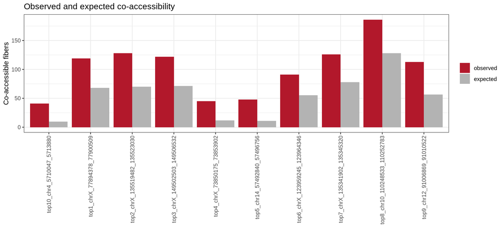

```r
if (nrow(selected)) {
  oe <- melt(selected[, .(pair_id, observed = as.numeric(co_access), expected = expected_co_access)],
           id.vars = "pair_id", variable.name = "count_type", value.name = "fibers")
  oe_plot <- ggplot(oe, aes(pair_id, fibers, fill = count_type)) +
    geom_col(position = "dodge") + theme_bw() +
    scale_fill_manual(values = c(observed = "#B2182B", expected = "grey70")) +
    labs(x = NULL, y = "Co-accessible fibers", fill = NULL,
         title = "Observed and expected co-accessibility") +
    theme(axis.text.x = element_text(angle = 90, hjust = 1, vjust = 0.5))
  print(oe_plot)
  ggsave(file.path(plot_dir, "LCL_top10_observed_expected.pdf"), oe_plot, width = 11, height = 5)
}
```

### Genome-wide volcano plot of cRE pair

From the top 10 co-accessible regions, 6/10 are on chrX, I wonder if chrX is enriched for co-accessible pairs genome wide?

- x = effect size (log2 odds ratio)
- y = sigificance (-log10 FDR)

Dotted line at the median log2 OR of all pairs + an open black ring around each of the ten selected pairs

```r
# filter for pairs with OR > 0
volcano <- pairs_dt[!is.na(fdr) & is.finite(OR) & OR > 0, .(
  chrom,
  log2_OR = log2(OR),
  # replace FDR = 0 with the smallest positive value
  neg_log10_fdr = -log10(pmax(fdr, .Machine$double.xmin)),
  significant = fdr < fdr_cutoff,
  direction = ifelse(OR > 1, "co-accessible", "co-inaccessible"))]

# add chrX as a separate color group
volcano[, chrom_class := ifelse(chrom == "chrX", "chrX",
  ifelse(direction == "co-accessible", "other, OR > 1", "other, OR < 1"))]

# median log OR across all pairs
median_log2_or <- median(volcano$log2_OR)

# top 10 pairs
chosen <- selected[, .(log2_OR = log2(OR),
  neg_log10_fdr = -log10(pmax(fdr, .Machine$double.xmin)))]
signif_pairs <- volcano[significant == TRUE]

cat(nrow(volcano), "tested pairs;", nrow(signif_pairs), "at FDR <", fdr_cutoff,
    "of which", sum(signif_pairs$direction == "co-accessible"), "have OR > 1 and",
    sum(signif_pairs$direction == "co-inaccessible"), "have OR < 1.\n")
```

```
## 233525 tested pairs; 3340 at FDR < 0.05 of which 3332 have OR > 1 and 8 have OR < 1.
```

```r
cat(sprintf("chrX: %d of %d tested (%.2f%%) but %d of %d significant (%.2f%%).\n",
    sum(volcano$chrom == "chrX"), nrow(volcano),
    100 * mean(volcano$chrom == "chrX"),
    sum(signif_pairs$chrom == "chrX"), nrow(signif_pairs),
    100 * mean(signif_pairs$chrom == "chrX")))
```

```
## chrX: 5149 of 233525 tested (2.20%) but 434 of 3340 significant (12.99%).
```

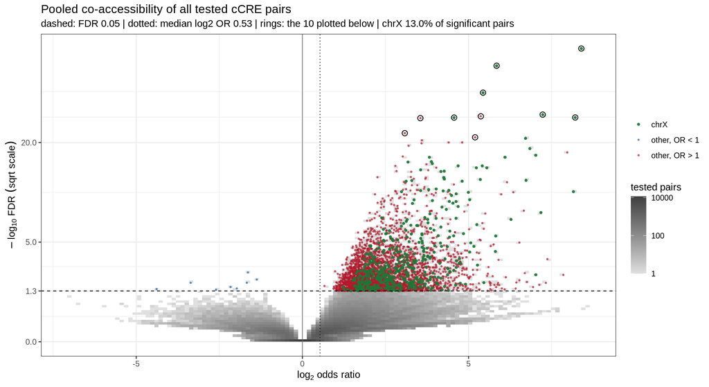

```r
volcano_plot <- ggplot(volcano, aes(log2_OR, neg_log10_fdr)) +
  geom_bin2d(bins = 120) +
  scale_fill_gradient(low = "grey88", high = "grey25", trans = "log10",
                      name = "tested pairs") +
  geom_point(data = signif_pairs[chrom != "chrX"], aes(colour = chrom_class),
             size = 0.5, alpha = 0.6) +
  geom_point(data = signif_pairs[chrom == "chrX"], aes(colour = chrom_class),
             size = 0.9, alpha = 0.9) +
  scale_colour_manual(values = c("chrX" = "#1B7837", "other, OR > 1" = "#B2182B",
                                 "other, OR < 1" = "#2166AC"), name = NULL) +
  geom_point(data = chosen, shape = 21, size = 2.4, colour = "black", fill = NA,
             stroke = 0.6) +
  geom_vline(xintercept = 0, linewidth = 0.3, colour = "grey40") +
  geom_vline(xintercept = median_log2_or, linetype = "dotted", linewidth = 0.4) +
  geom_hline(yintercept = -log10(fdr_cutoff), linetype = "dashed", linewidth = 0.4) +
  scale_y_sqrt(breaks = c(0, 1.3, 5, 20, 50, 100)) +
  theme_bw(base_size = 11) +
  labs(x = expression(log[2]~odds~ratio), y = expression(-log[10]~FDR~(sqrt~scale)),
       title = "Pooled co-accessibility of all tested cCRE pairs",
       subtitle = sprintf(paste("dashed: FDR %.2f | dotted: median log2 OR %.2f |",
         "rings: the %d plotted below | chrX %.1f%% of significant pairs"),
         fdr_cutoff, median_log2_or, nrow(chosen),
         100 * mean(signif_pairs$chrom == "chrX")))
print(volcano_plot)
```

```r
ggsave(file.path(plot_dir, "LCL_coaccess_volcano.pdf"), volcano_plot,
       width = 9, height = 6)
```

### Load fibers and assign accessibility

`load_region()` and `label_reads()` come from `parsing_footprints_functions.r`; `coaccess_2x2()` comes from `stats_testing_functions.r`.

For each of the ten selected pairs, this reloads the fibers from all 31 samples in that pair’s plotting window and get the fibers cover each cCRE and which are accessible. It then builds the 2×2 table

```r
pair_data <- list()
if (isTRUE(params$make_plots) && nrow(selected)) {
  for (i in seq_len(nrow(selected))) {
    pair <- selected[i]
    region <- list(chrom = pair$chrom, start = pair$region_start, end = pair$region_end)
    cre1 <- list(start = pair$cre1_start, end = pair$cre1_end)
    cre2 <- list(start = pair$cre2_start, end = pair$cre2_end)

    # pull the data for this window from all 31 samples, get spanning reads from aligned blocks
    res <- load_region(region, samples, paths$root, paths$fire_root,
      fire_ver = paths$fire_ver, tabix_bin = paths$tabix_bin,
      span_source = "aligned_blocks")
    labels <- label_reads(res, cre1, cre2, fire_overlap_fraction = fire_overlap_fraction)
    pair_data[[pair$pair_id]] <- list(pair = pair, region = region,
      cre1 = cre1, cre2 = cre2, res = res, labels = labels,
      counts = coaccess_2x2(labels))
  }
}

head(pair_data[[selected$pair_id[1]]])
```

```
## $pair
##                                                       CRE_pair
##                                                         <char>
## 1: EH38D6116107.EH38E3938024.PLS-EH38D4291982.EH38E2759288.PLS
##                             CRE1                          CRE2  dist cre1_start
##                           <char>                        <char> <int>      <int>
## 1: EH38D6116107.EH38E3938024.PLS EH38D4291982.EH38E2759288.PLS  3432   77895378
##    cre1_end cre2_start cre2_end  chrom CRE_pair_labels co_closed CRE1_access
##       <int>      <int>    <int> <char>          <char>     <int>       <int>
## 1: 77895728   77899160 77899509   chrX         PLS-PLS        97           6
##    CRE2_access co_access
##          <int>     <int>
## 1:           4       119
##                                                         pval fisher_estimate
##                                                        <num>           <num>
## 1: 0.0000000000000000000000000000000000000000000000002058668        310.5465
##                                                       pval_raw n_shared_reads
##                                                          <num>          <int>
## 1: 0.000000000000000000000000000000000000000000000000008110295            226
##    n_contributing_samples co_inaccess    OR or_haldane expected_co_access
##                     <int>       <int> <num>      <num>              <num>
## 1:                     31          97   336   398.3333           68.03097
##    observed_expected_ratio excess_fraction zero_access_cre1 zero_access_cre2
##                      <num>           <num>           <lgcl>           <lgcl>
## 1:                1.749203       0.2255267            FALSE            FALSE
##                                                     fdr
##                                                   <num>
## 1: 0.00000000000000000000000000000000000000000004807504
##                                                  fdr_raw min_shared_reads
##                                                    <num>            <int>
## 1: 0.000000000000000000000000000000000000000000001893957               20
##    dataset analysis_scope n_samples     coverage_mode read_rule
##     <char>         <char>     <int>            <char>    <char>
## 1:     LCL    genome-wide        31 aligned_blocks_v1   contain
##    fire_overlap_fraction min_dist max_dist pseudocount n_genes
##                    <num>    <int>    <int>       <int>   <int>
## 1:                   0.5      500    20000           1       2
##                                gene_ids  gene_names region_start region_end
##                                  <char>      <char>        <int>      <int>
## 1: ENSG00000102158.22;ENSG00000131174.7 COX7B;MAGT1     77894378   77900509
```

[output cut: 277 more lines]

```
## 868: AL29AL40AL53_bc2171bc2141bc2132_18916 m84241_250514_222554_s2/215945542/ccs
## 869:  AL29AL40AL53_bc2171bc2141bc2132_18916 m84241_250815_182408_s1/27591040/ccs
##                                sample_name shared   acc1   acc2 config
##                                     <char> <lgcl> <lgcl> <lgcl> <fctr>
##   1:                      AL6_bc2162_19093  FALSE  FALSE  FALSE   <NA>
##   2:                      AL6_bc2162_19093  FALSE  FALSE  FALSE   <NA>
##   3:                      AL6_bc2162_19093  FALSE  FALSE  FALSE   <NA>
##   4:                      AL6_bc2162_19093  FALSE   TRUE  FALSE   <NA>
##   5:                      AL6_bc2162_19093  FALSE  FALSE  FALSE   <NA>
##  ---
## 865: AL29AL40AL53_bc2171bc2141bc2132_18916  FALSE  FALSE  FALSE   <NA>
## 866: AL29AL40AL53_bc2171bc2141bc2132_18916  FALSE  FALSE  FALSE   <NA>
## 867: AL29AL40AL53_bc2171bc2141bc2132_18916  FALSE  FALSE  FALSE   <NA>
## 868: AL29AL40AL53_bc2171bc2141bc2132_18916  FALSE  FALSE  FALSE   <NA>
## 869: AL29AL40AL53_bc2171bc2141bc2132_18916  FALSE  FALSE  FALSE   <NA>
```

For each of the ten selected pairs, 1) get every fiber that covers both cCREs, labelled with its sample, donor and accessibility state 2) summary of how much each sample contributes to the pair’s 2×2 table

```r
for (id in names(pair_data)) {
  entry <- pair_data[[id]]
  pair <- entry$pair
  read_labels <- copy(entry$labels)[shared == TRUE]
  read_labels[, donor := sample_meta$donor[match(sample_name, sample_meta$sample_name)]]
  read_labels[, `:=`(pair_id = pair$pair_id, CRE_pair = pair$CRE_pair)]
  fwrite(read_labels, file.path(table_dir, paste0(pair$pair_id, "_read_labels.tsv.gz")), sep = "\t")
  contributions <- read_labels[, .(n_shared = .N, co_access = sum(acc1 & acc2),
    CRE1_access = sum(acc1 & !acc2), CRE2_access = sum(!acc1 & acc2),
    co_closed = sum(!acc1 & !acc2)), by = .(pair_id, sample_name, donor)]
  fwrite(contributions, file.path(table_dir, paste0(pair$pair_id, "_sample_counts.tsv")), sep = "\t")
}

id <- names(pair_data)[1]
pair_id <- pair_data[[id]]$pair$pair_id

read_labels <- fread(file.path(table_dir, paste0(pair_id, "_read_labels.tsv.gz")))
print(head(read_labels, 10))
```

```
##                                                         key       sample_name
##                                                      <char>            <char>
##  1:   AL6_bc2162_19093 m84241_250907_013920_s4/20976881/ccs  AL6_bc2162_19093
##  2:  AL6_bc2162_19093 m84241_250907_013920_s4/250153577/ccs  AL6_bc2162_19093
##  3:   AL6_bc2162_19093 m84241_250514_222554_s2/67045057/ccs  AL6_bc2162_19093
##  4:  AL8_bc2170_19151 m84241_250325_230544_s1/175572478/ccs  AL8_bc2170_19151
##  5:  AL8_bc2170_19151 m84241_250325_230544_s1/195953438/ccs  AL8_bc2170_19151
##  6:  AL8_bc2170_19151 m84241_250325_230544_s1/180619572/ccs  AL8_bc2170_19151
##  7:  AL8_bc2170_19151 m84241_241120_172940_s3/235672428/ccs  AL8_bc2170_19151
##  8:  AL10_bc2178_19130 m84241_250311_201728_s2/53219847/ccs AL10_bc2178_19130
##  9: AL10_bc2178_19130 m84241_250311_201728_s2/201592011/ccs AL10_bc2178_19130
## 10:  AL16_bc2114_18508 m84241_250515_002859_s3/22282809/ccs AL16_bc2114_18508
##     shared   acc1   acc2          config   donor                     pair_id
##     <lgcl> <lgcl> <lgcl>          <char>  <char>                      <char>
##  1:   TRUE   TRUE   TRUE both accessible NA19093 top1_chrX_77894378_77900509
```

[output cut: 21 more lines]

```r
sample_counts <- fread(file.path(table_dir, paste0(pair_id, "_sample_counts.tsv")))
print(sample_counts)
```

```
##                         pair_id                           sample_name   donor
##                          <char>                                <char>  <char>
##  1: top1_chrX_77894378_77900509                      AL6_bc2162_19093 NA19093
##  2: top1_chrX_77894378_77900509                      AL8_bc2170_19151 NA19151
##  3: top1_chrX_77894378_77900509                     AL10_bc2178_19130 NA19130
##  4: top1_chrX_77894378_77900509                     AL16_bc2114_18508 NA18508
##  5: top1_chrX_77894378_77900509                     AL18_bc2130_18504 NA18504
##  6: top1_chrX_77894378_77900509                     AL19_bc2138_18861 NA18861
##  7: top1_chrX_77894378_77900509                     AL20_bc2146_19209 NA19209
##  8: top1_chrX_77894378_77900509                     AL27_bc2155_18913 NA18913
##  9: top1_chrX_77894378_77900509                     AL28_bc2163_19153 NA19153
## 10: top1_chrX_77894378_77900509                     AL30_bc2179_18510 NA18510
## 11: top1_chrX_77894378_77900509                     AL38_bc2125_18499 NA18499
## 12: top1_chrX_77894378_77900509                     AL39_bc2133_19207 NA19207
## 13: top1_chrX_77894378_77900509                     AL43_bc2149_18511 NA18511
```

[output cut: 55 more lines]

### Single molecule view of top 10 co-accessibel regions

prepares the data for the single molecule plots of the ten selected pairs. For each pair, it picks which read to draw: those that span the whole window, with co-accessible ones first, and plots at most 500 reads. It then loads the m6A, nucleosome and TF-footprint tracks for just those fibers

```r
max_drawn <- 500L
display_data <- list()
for (id in names(pair_data)) {
  entry <- pair_data[[id]]
  region <- entry$region
  # only reads whose alignment covers the whole window
  spanning <- entry$res$spans[start <= region$start & end >= region$end, key]
  drawn_labels <- copy(entry$labels)[shared == TRUE & key %in% spanning]
  setorder(drawn_labels, config)
  n_spanning <- nrow(drawn_labels)
  if (n_spanning > max_drawn) drawn_labels <- drawn_labels[seq_len(max_drawn)]

  display_res <- load_ft_tracks(copy(entry$res), keys = drawn_labels$key,
    ft_root = paths$ft_root, tabix_bin = paths$tabix_bin,
    nuc_source = "ft", tf_source = "recalled_tf", tf_root = paths$tf_root)
  for (track in c("spans", "blocks", "elements", "m6a", "nuc", "size_fps")) {
    if (!is.null(display_res[[track]]) && nrow(display_res[[track]]))
      display_res[[track]][, sample_name := "pooled"]
  }
  display_res$samples <- "pooled"
  drawn_labels[, sample_name := "pooled"]

  cres_here <- cre_universe[chrom == region$chrom & end > region$start & start < region$end]
  region_res <- coaccess_region_result(display_res, entry$cre1, entry$cre2,
    drawn_labels, cres = cres_here)

  # order_reads() ranks "both accessible" first
  rid_levels <- rev(levels(region_res$rids_df$RID))
  for (tb in c("reads", "rids_df", "fire", "nucs", "fps", "fps_infire")) {
    if (!is.null(region_res[[tb]]) && nrow(region_res[[tb]]))
      region_res[[tb]][["RID"]] <- factor(as.character(region_res[[tb]][["RID"]]),
                                          levels = rid_levels)
  }


  pk <- as.data.frame(cres_here)
  cls <- factor(pk$CRE_label, levels = c(intersect(CCRE_CLASSES, pk$CRE_label),
    setdiff(unique(pk$CRE_label), CCRE_CLASSES)))
  pk <- pk[order(cls, pk$start), , drop = FALSE]
  peaks_df <- data.frame(chr = pk$chrom, start = pk$start, end = pk$end,
    group = as.character(pk$CRE_label))
  display_data[[id]] <- list(region_res = region_res, peaks_df = peaks_df,
    n_drawn = nrow(drawn_labels), n_spanning = n_spanning)
}
```

For each of the ten pairs, this chunk builds a multi-panel single-fiber figure and stores it in fiber_plots. From top to bottom, the panels are:

- the m6A fraction along the window
- the cCRE track
- m6A per fiber
- nucleosomes, FIRE elements and TF footprints, one row per fiber

```r
fiber_plots <- list()
for (id in names(pair_data)) {
  entry <- pair_data[[id]]
  pair <- entry$pair
  region <- entry$region
  counts <- entry$counts
  display <- display_data[[id]]
  region_res <- display$region_res

  subtitle <- sprintf("%s:%d-%d", region$chrom, region$start, region$end)
  subtitle <- paste0(subtitle, "\n", sprintf(paste0(
    "%d fibers fully cover both cCREs: both %d | CRE1 only %d | CRE2 only %d | neither %d",
    " | Fisher OR (table + 1) = %.2f, p = %.2g"), counts$n_shared,
    counts$both, counts$cre1_only, counts$cre2_only, counts$neither,
    counts$fisher_or, counts$fisher_p))

  raster_height <- max(2, 0.025 * display$n_drawn + 0.3)
  heights <- c(pileup = 1.5, peaks = 0.3 + 0.3 * length(unique(display$peaks_df$group)),
    reads = raster_height, fire_fiberHMM = raster_height)
  read_theme <- list(axis.ticks.y = element_blank(), panel.grid.major.y = element_blank())
  fiber_plots[[id]] <- plot_region_panels(region_res,
    plot_name = paste(id, pair$gene_names, pair$CRE_pair_labels,
      sprintf("%d of %d window-spanning fibers drawn, co-accessible first",
              display$n_drawn, display$n_spanning), sep = " | "),
    subtitle = subtitle, peaks_df = display$peaks_df, highlight = region_res$highlight,
    linewidth = 1.1, expand = TRUE, heights = heights,
    profile_options = list(colour_by = "group", colors = cluster_palette("pooled"),
      y_col = "frac", linewidth = 0.4, facet_scales = "fixed",
      facet_space = "fixed", require_data = TRUE),
    read_options = list(tile_width = 8, tile_height = 0.85,
      backbone_col = BACKBONE_COL, arrows = FALSE,
      base_colors = c(A = M6A_COL), require_data = TRUE),
    peaks_options = list(variant = "intervals"),
    footprint_options = list(draw_order = c("linker", "nucleosome", "FIRE element",
      rev(region_res$size_levels)), backbone = FALSE, always = TRUE,
      legend_title = NULL, legend_drop = FALSE, legend_linewidth = 3),
    theme_options = list(base = "bw", base_size = 11,
      pileup = list(strip.text.y = element_text(angle = 0)),
      reads = read_theme, fire_fiberHMM = read_theme),
    y_labels = c(pileup = "m6A fraction", reads = "m6A",
      fire_fiberHMM = "ft nucleosomes + FIRE + FiberHMM TF"),
    panel_names = c(peaks = "cres", pileup = "m6a_prop", reads = "m6a", fire_fiberHMM = "reads"))
}
```

```r
for (id in names(pair_data)) {
  fig_height <- 6 + 0.05 * display_data[[id]]$n_drawn
  ggsave(file.path(plot_dir, paste0(id, "_reads.pdf")),
    fiber_plots[[id]]$combined, width = 12, height = fig_height, limitsize = FALSE)
}
```

````r
show_region_figures <- function(plots, heights, titles, fig_dir, header = "##", label_prefix = "fiber-") {
  old_opts <- options(knitr.duplicate.label = "allow")
  on.exit(options(old_opts), add = TRUE)
  fig_path <- if (isTRUE(getOption("knitr.in.progress"))) "" else
    sprintf(", fig.path='%s/'", fig_dir)
  for (id in names(plots)) {
    child <- paste0(header, " ", titles[[id]], "\n\n",
      "```{r ", label_prefix, id, ", echo=FALSE, fig.width=12, fig.height=", heights[[id]], fig_path, "}\n",
      "print(plots[[\"", id, "\"]]$combined)\n",
      "```\n")
    cat(knitr::knit_child(text = child, envir = environment(), quiet = TRUE), sep = "\n")
  }
}
if (length(pair_data)) {
  show_region_figures(fiber_plots,
    heights = sapply(names(pair_data), function(id) 6 + 0.05 * display_data[[id]]$n_drawn),
    titles = sapply(names(pair_data), function(id)
      paste0(id, ": ", pair_data[[id]]$pair$gene_names)),
    fig_dir = plot_dir)
} else {
  cat("No fiber plots requested or no qualifying pairs.\n")
}
````

## top1_chrX_77894378_77900509: COX7B;MAGT1

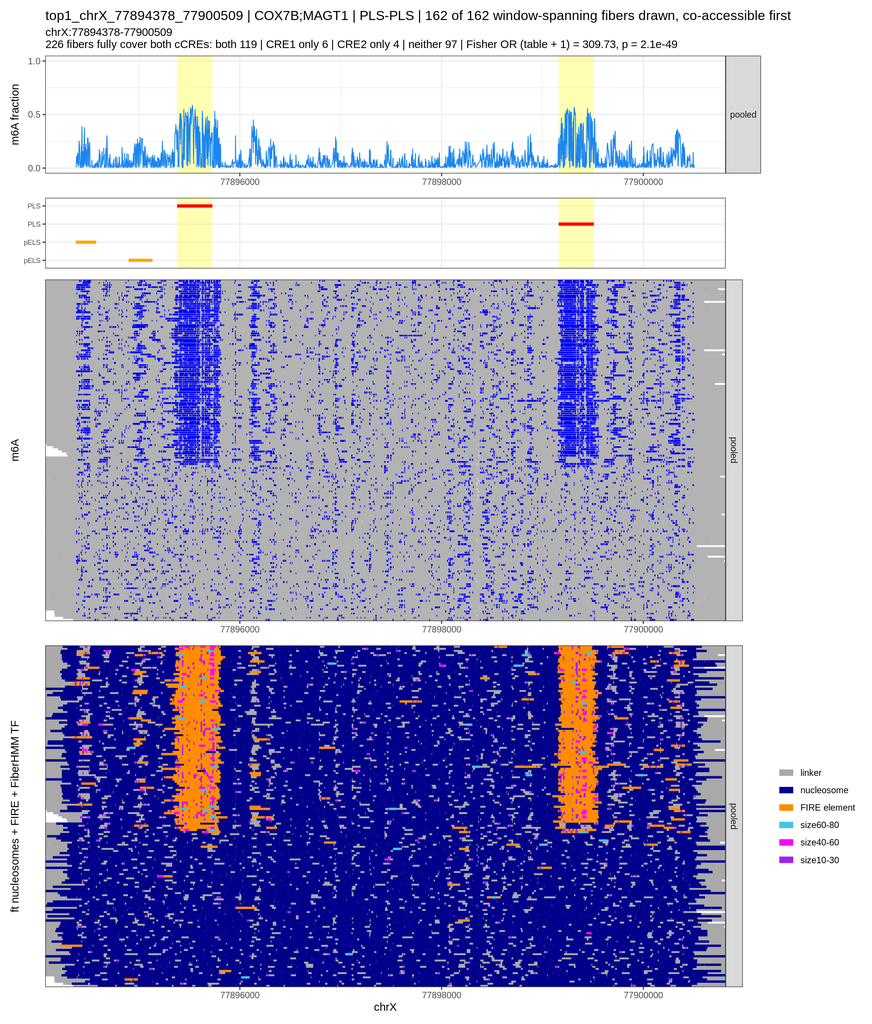

## top2_chrX_135519482_135523030: INTS6L;INTS6L-AS1

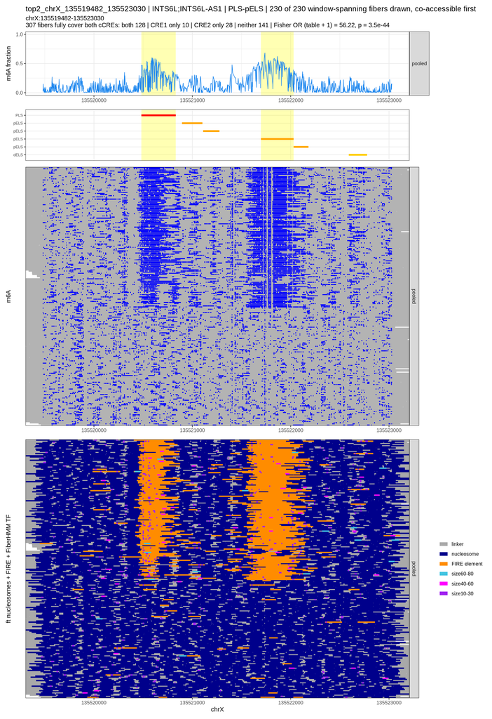

## top3_chrX_149502503_149506532: IDS

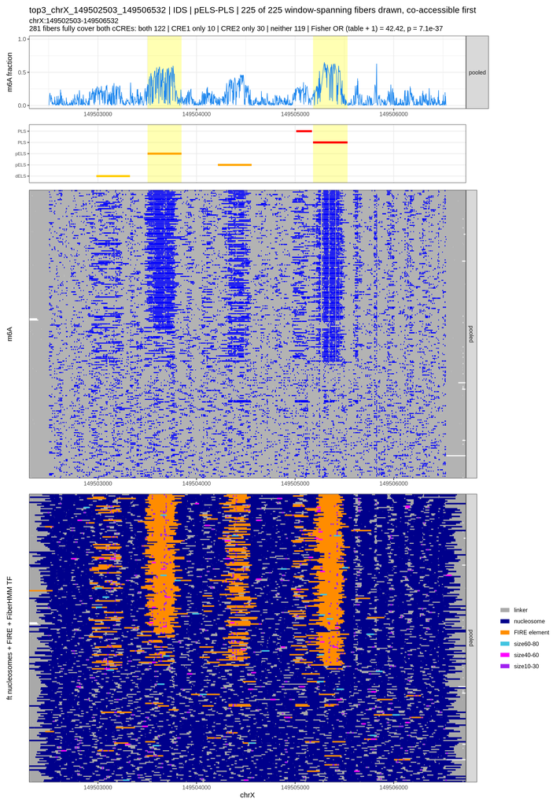

## top4_chrX_73850175_73853902: ENSG00000278039;XIST

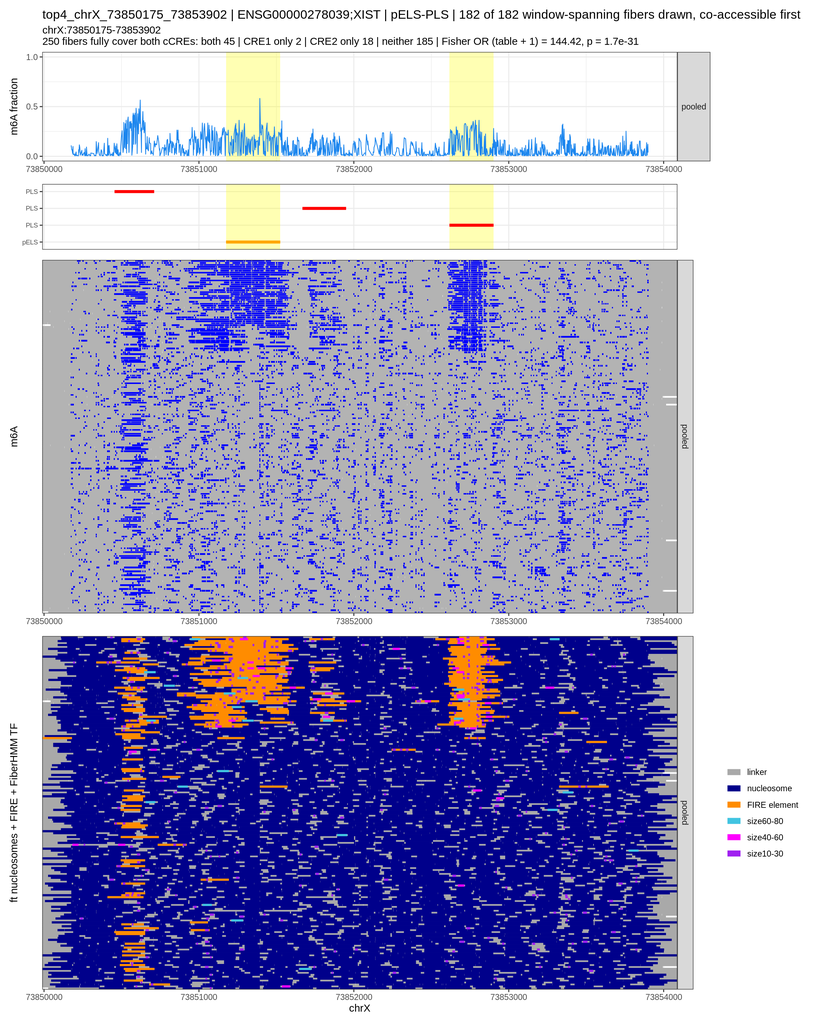

## top5_chr14_57492840_57496756: CCDC198

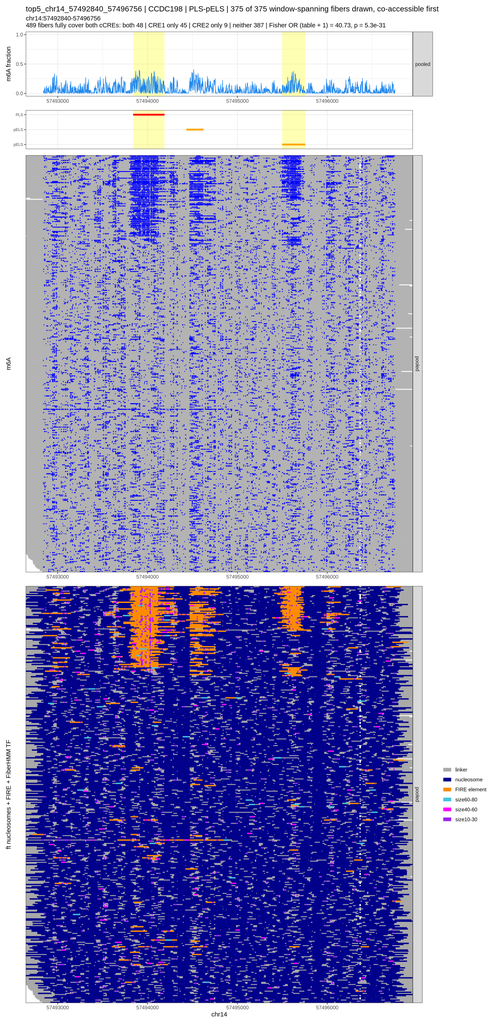

## top6_chrX_123959245_123964346: STAG2;STAG2-AS1

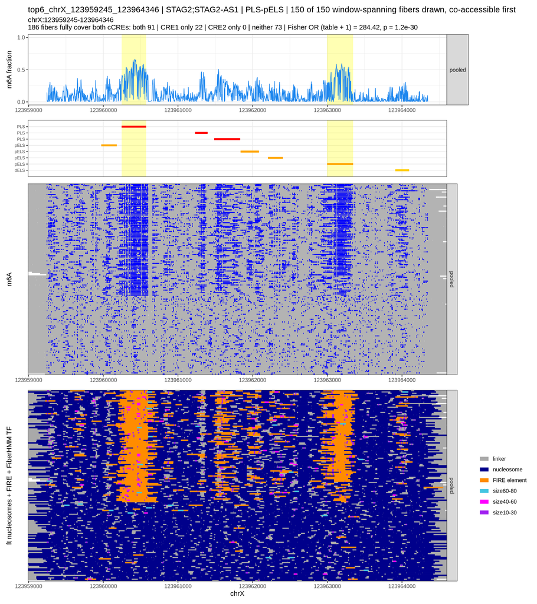

## top7_chrX_135341902_135345320: ZNF449;ZNF75D

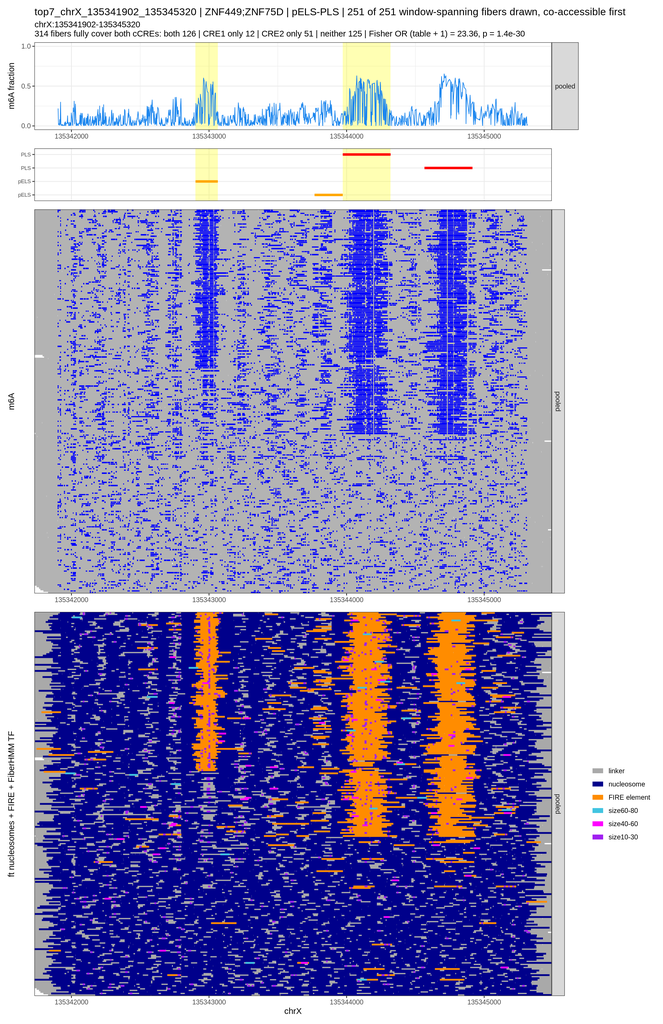

## top8_chr10_110248533_110252783: ENSG00000214067

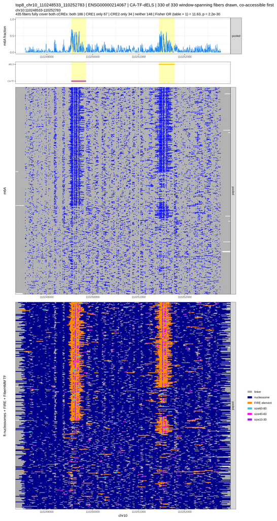

## top9_chr12_91006869_91010522: EPYC

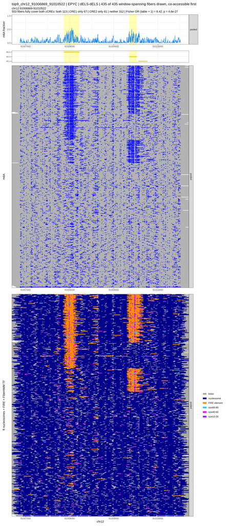

## top10_chr4_5710047_5713880: EVC;EVC2

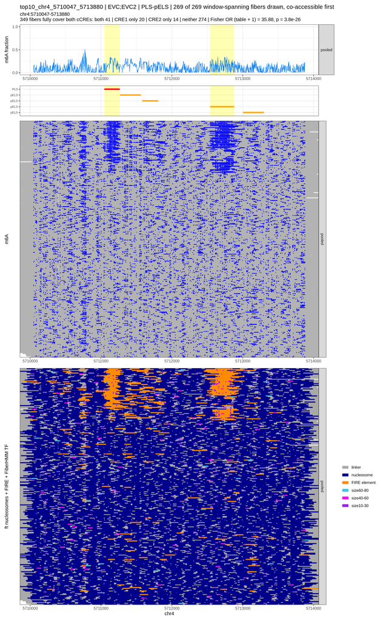

# Enrichment of co-accessible CREs on chrX

ChrX is enriched for co-accessible pairs, and check if this is because of X chr inactivation

### donor sex against chrX inflation

1. Is the excess of significant ChrX pairs come from X inactivation and not from co-accessibility?
- infer donor sex from chrx read depth
- measures how inflated chrx co-accessibility is relative to the same sample’s autosomes -> if this is because of x inactivation, female samples should be inflated and males should not

x_depth: the average number of shared fibers per pair on chrX, divided by the same average on autosomes. It compares chrX coverage with autosomal coverage in the same sample. It is about 1 with two X copies (female) and about 0.5 with one (male), so it is used to infer sex - oe_chrX: observed over expected co-accessible fibers on chrX pairs. A value above 1 means more joint accessibility than independence predicts - oe_auto: the same measure for autosomal pairs

```r
# min # of spanning reads = 6
xci_min_fibers <- 6L
counts_file <- file.path(coaccess_dir, "LCL_pair_sample_counts.tsv.gz")
stopifnot(file.exists(counts_file))

# For each sample, count
  # 1. the total number of shared reads for each pair
  # 2. number of pairs
  # 3. sum of observed co-accessible fibers
  # 4. sum of expcted co-accessible fibers (both + CRE1 only) x(both + CRE2 only) / shared reads
per_sample <- fread(cmd = sprintf(
  "zcat %s | awk -F'\\t' -v OFS='\\t' -v m=%d '
     NR == 1 { next }
     { cls = ($6 == \"chrX\") ? \"chrX\" : (($6 == \"chrY\") ? \"chrY\" : \"autosome\")
       k = $7 SUBSEP cls
       cov[k] += $9; np[k]++
       if ($9 >= m) { obs[k] += $5; ex[k] += ($5 + $3) * ($5 + $4) / $9 } }
     END { for (k in cov) { split(k, p, SUBSEP)
             print p[1], p[2], cov[k], np[k], obs[k], ex[k] } }'",
  shQuote(counts_file), xci_min_fibers),
  col.names = c("sample_name", "class", "fibers", "n_pairs", "obs", "exp"))

stopifnot(setequal(per_sample$sample_name, samples))


wide <- dcast(per_sample, sample_name ~ class,
              value.var = c("fibers", "n_pairs", "obs", "exp"))
wide[, `:=`(
  x_depth = (fibers_chrX / n_pairs_chrX) / (fibers_autosome / n_pairs_autosome),
  oe_chrX = obs_chrX / exp_chrX,
  oe_auto = obs_autosome / exp_autosome)]
wide[, oe_ratio := oe_chrX / oe_auto]

print(wide)
```

```
## Key: <sample_name>
##                               sample_name fibers_autosome fibers_chrX
##                                    <char>           <int>       <int>
##  1:                     AL10_bc2178_19130         1525600       18546
##  2:                     AL16_bc2114_18508          846512       22024
##  3:                     AL18_bc2130_18504         1410864       17342
##  4:                     AL19_bc2138_18861          771229       18734
##  5:                     AL20_bc2146_19209         2434004       31406
##  6:                     AL27_bc2155_18913          771466       10608
##  7:                     AL28_bc2163_19153         1950599       24436
##  8: AL29AL40AL53_bc2171bc2141bc2132_18916         3174050       85009
##  9:                     AL30_bc2179_18510         1804748       22647
## 10:                     AL38_bc2125_18499         1278338       19733
## 11:                     AL39_bc2133_19207         1078800       13510
## 12:                     AL43_bc2149_18511         1005182       27234
```

[output cut: 126 more lines]

```r
# infer sex based on chrx coverage: females should have near 1 coverage and males should have 0.5
sex_depth_cut <- 0.9
stopifnot(!any(wide$x_depth > 0.8 & wide$x_depth < 1.0))
wide[, sex := ifelse(x_depth >= sex_depth_cut, "female (XX)", "male (XY)")]
sample_sex <- wide[, .(sample_name, sex, x_depth, oe_chrX, oe_auto, oe_ratio)]
sample_sex[, donor := sample_meta$donor[match(sample_name, sample_meta$sample_name)]]
fwrite(sample_sex, file.path(table_dir, "LCL_xci_sample_sex.tsv"), sep = "\t")


f_ratio <- sample_sex[sex == "female (XX)", oe_ratio]
m_ratio <- sample_sex[sex == "male (XY)", oe_ratio]
sep_p <- complete_separation_pvalue(f_ratio, m_ratio)
cat(sprintf("%d female and %d male donors; median chrX/autosome O/E %.3f vs %.3f.\n",
            length(f_ratio), length(m_ratio), median(f_ratio), median(m_ratio)))
```

```
## 16 female and 15 male donors; median chrX/autosome O/E 1.401 vs 1.006.
```

```r
cat(if (is.na(sep_p)) "The two groups overlap.\n" else
  sprintf("Every female sample exceeds every male sample; exact one-sided p = %.3g.\n", sep_p))
```

```
## Every female sample exceeds every male sample; exact one-sided p = 3.33e-09.
```

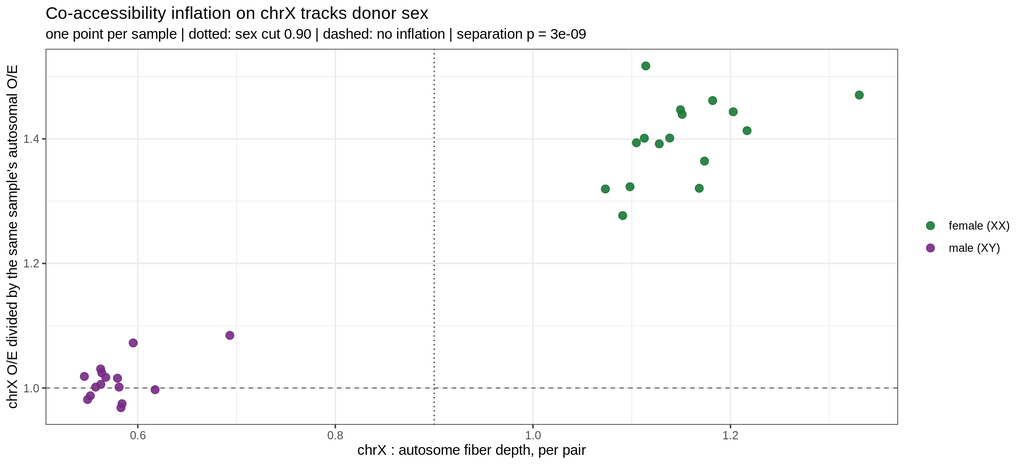

```r
panel_a <- ggplot(sample_sex, aes(x_depth, oe_ratio, colour = sex)) +
  geom_hline(yintercept = 1, linetype = "dashed", linewidth = 0.4, colour = "grey40") +
  geom_vline(xintercept = sex_depth_cut, linetype = "dotted", linewidth = 0.4) +
  geom_point(size = 2.6, alpha = 0.9) +
  scale_colour_manual(values = c("female (XX)" = "#1B7837", "male (XY)" = "#762A83"),
                      name = NULL) +
  theme_bw(base_size = 11) +
  labs(x = "chrX : autosome fiber depth, per pair",
       y = "chrX O/E divided by the same sample's autosomal O/E",
       title = "Co-accessibility inflation on chrX tracks donor sex",
       subtitle = sprintf(paste("one point per sample | dotted: sex cut %.2f |",
         "dashed: no inflation%s"), sex_depth_cut,
         if (is.na(sep_p)) "" else sprintf(" | separation p = %.1g", sep_p)))
print(panel_a)
```

```r
ggsave(file.path(plot_dir, "LCL_xci_sex_vs_inflation.pdf"), panel_a,
       width = 7.5, height = 5)
```

### Fisher test separately on female vs male

Do 2x2 table (pooled counts, +1 pseudocount, two-sided Fisher test, BH correction) separately on female samples and on male samples

- whether chrX’s excess of significant pairs appears in females but not in males, which is what X-inactivation would predict

Input: `LCL_pair_sample_counts.tsv.gz` has one row per pair per sample, with these columns: pair, co_closed, CRE1 only, CRE2 only, both, chromosome, sample name, donor, shared fibers

Output: `LCL_xci_sex_split_pairs.tsv.gz`

| Column | Meaning |
| --- | --- |
| `sex` | The donor group, female (XX) or male (XY). |
| `tested` | The number of cCRE pairs tested in that group. These are the pairs with at least 50 shared fibers in both groups, so the number is the same for both rows. |
| `chrX_tested` | How many of those pairs are on chrX. This is also the same for both rows. |
| `significant` | The number of pairs that pass all three criteria in that group: FDR below 0.05, OR above 1, and observed co-accessibility above expected. |
| `chrX_significant` | How many of the significant pairs are on chrX. |
| `median_chrX_fibers` | The median number of shared fibers on chrX pairs in that group. It shows how much depth the chrX tests had. |
| `pct_chrX_of_significant` | The share of significant pairs that are on chrX: `chrX_significant` / `significant` × 100. |

```r
# min # of reads spanning both CREs
xci_min_split <- 50L

# Fisher testing is provided by stats_testing_functions.r.


# summarize counts by pair and sex
fem <- sample_sex[sex == "female (XX)", sample_name]

# combines the per sample counts into one 2×2 table per cCRE pair for females and one for males
  # 1. group males and females
  # 2. add up the counts for each pair within each group -> for every pair, it sums the four fiber counts and the number of shared fibers across all samples of that sex
  # 3. For each sample that has at least 6 shared fibers on a pair, it adds that sample’s observed number of fibers open at both cCREs
split_counts <- fread(cmd = sprintf("zcat %s | awk -F'\\t' -v OFS='\\t' -v m=%d %s",
  shQuote(counts_file), xci_min_fibers, shQuote(sprintf(
  'BEGIN { split("%s", s, " "); for (i in s) fem[s[i]] = 1 }
   NR == 1 { next }
   { g = ($7 in fem) ? "female (XX)" : "male (XY)"; k = $1 SUBSEP g
     cc[k] += $2; c1[k] += $3; c2[k] += $4; bo[k] += $5; n[k] += $9
     if ($9 >= m) { obs[k] += $5; ex[k] += ($5 + $3) * ($5 + $4) / $9 } }
   END { for (k in n) { split(k, p, SUBSEP)
           print p[1], p[2], cc[k], c1[k], c2[k], bo[k], n[k], obs[k], ex[k] } }',
  paste(fem, collapse = " ")))),
  col.names = c("CRE_pair", "sex", "co_closed", "CRE1_access", "CRE2_access", "co_access", "n_shared_reads", "obs", "exp"))

# check if there are pairs that are not tested
untested <- split_counts[!CRE_pair %in% pairs_dt$CRE_pair]
stopifnot(all(untested$n_shared_reads == 0L))

# keep only the tested paris
split_counts <- split_counts[CRE_pair %in% pairs_dt$CRE_pair]
split_counts[, chrom := pairs_dt$chrom[match(CRE_pair, pairs_dt$CRE_pair)]]
stopifnot(!anyNA(split_counts$chrom),
          split_counts[, all(n_shared_reads ==
            co_closed + CRE1_access + CRE2_access + co_access)])

# keep pairs both panels can speak to, then test each panel on its own fibers
depth <- dcast(split_counts, CRE_pair ~ sex, value.var = "n_shared_reads")
keep <- depth[get("female (XX)") >= xci_min_split & get("male (XY)") >= xci_min_split,
              CRE_pair]
split_test <- split_counts[CRE_pair %in% keep]
split_test[, `:=`(
  OR = ((co_closed + 1) * (co_access + 1)) / ((CRE1_access + 1) * (CRE2_access + 1)),
  pval = fisher_test_counts(cbind(co_closed, CRE1_access, CRE2_access, co_access),
    pseudocount = 1L, estimate = FALSE, include_raw = FALSE)$pval)]
split_test[, fdr := adjust_bh(pval), by = sex]
split_test[, significant := fdr < fdr_cutoff & OR > 1 & obs > exp]
fwrite(split_test, file.path(table_dir, "LCL_xci_sex_split_pairs.tsv.gz"), sep = "\t")

# result table for chrX
split_summary <- split_test[, .(tested = .N, chrX_tested = sum(chrom == "chrX"),
  significant = sum(significant), chrX_significant = sum(significant & chrom == "chrX"),
  median_chrX_fibers = median(n_shared_reads[chrom == "chrX"])), by = sex]
split_summary[, pct_chrX_of_significant := 100 * chrX_significant / significant]
print(split_summary, digits = 2)
```

```
##            sex tested chrX_tested significant chrX_significant
##         <char>  <int>       <int>       <int>            <int>
## 1: female (XX) 168959        2904        1122              248
## 2:   male (XY) 168959        2904         461                4
##    median_chrX_fibers pct_chrX_of_significant
##                 <num>                   <num>
## 1:                171                   22.10
## 2:                 79                    0.87
```

### genome wide co-accessibility separated

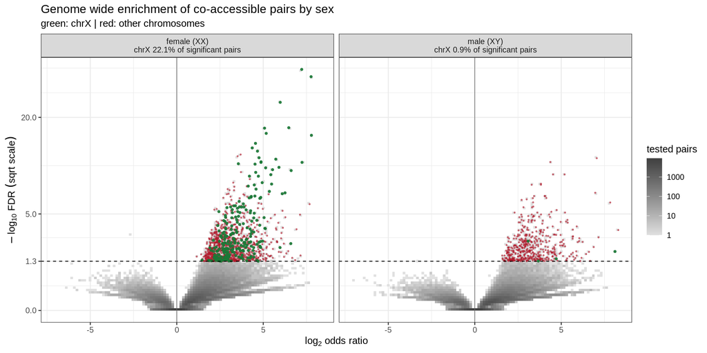

```r
volc_split <- split_test[is.finite(OR) & OR > 0, .(sex, chrom, significant,
  log2_OR = log2(OR), neg_log10_fdr = -log10(pmax(fdr, .Machine$double.xmin)))]
volc_split[, chrom_class := ifelse(chrom == "chrX", "chrX", "other")]
sig_split <- volc_split[significant == TRUE]
facet_note <- split_summary[, setNames(sprintf("%s\nchrX %.1f%% of significant pairs",
  sex, pct_chrX_of_significant), sex)]

volc_by_sex <- ggplot(volc_split, aes(log2_OR, neg_log10_fdr)) +
  geom_bin2d(bins = 100) +
  scale_fill_gradient(low = "grey88", high = "grey25", trans = "log10",
                      name = "tested pairs") +
  geom_point(data = sig_split[chrom_class != "chrX"], colour = "#B2182B",
             size = 0.4, alpha = 0.5) +
  geom_point(data = sig_split[chrom_class == "chrX"], colour = "#1B7837",
             size = 0.9, alpha = 0.9) +
  geom_hline(yintercept = -log10(fdr_cutoff), linetype = "dashed", linewidth = 0.4) +
  geom_vline(xintercept = 0, linewidth = 0.3, colour = "grey40") +
  facet_wrap(~ sex, nrow = 1, labeller = labeller(sex = facet_note)) +
  scale_y_sqrt(breaks = c(0, 1.3, 5, 20, 50)) +
  theme_bw(base_size = 11) +
  labs(x = expression(log[2]~odds~ratio), y = expression(-log[10]~FDR~(sqrt~scale)),
       title = "Genome wide enrichment of co-accessible pairs by sex",
       subtitle = "green: chrX | red: other chromosomes")
print(volc_by_sex)
```

```r
ggsave(file.path(plot_dir, "LCL_xci_sex_split_volcano.pdf"), volc_by_sex,
       width = 11, height = 5.5)
```

# Co-accessibility with X-inactivation excluded

ChrX on female is excluded, chrX pairs are couted using male samples only - `LCL_coaccess_noXCI.py` -> this is because males only have one X, and it’s active, so there is no closed inactivated chrX to inflate the table

1. call sex using chrx coverage - computes the average spanning fibers per CRE pair on chrx and on autosomes -> chrx spanning fibers/autosomes spanning fibers = depth
   - depth > 0.9 the female
2. remove chrx counts from females -> every per sample counts row on chrX from females are removed
3. for each pair, the 2x2 tables are summed across remaing rows, chrX comes from males only
4. run fisher test on the new tables without female chrx

```r
noxci_dir <- file.path(coaccess_dir, "noXCI")
table_dir_noxci <- file.path(coaccess_dir, "no_female_chrx", "tables")
plot_dir_noxci <- file.path(coaccess_dir, "no_female_chrx", "plots")
for (d in c(table_dir_noxci, plot_dir_noxci)) dir.create(d, recursive = TRUE, showWarnings = FALSE)

pairs_file_noxci <- file.path(noxci_dir, "LCL_coaccess_pairs_noXCI.tsv.gz")
pairs_noxci <- fread(pairs_file_noxci)
sex_noxci <- fread(file.path(noxci_dir, "LCL_sample_sex_noXCI.tsv"))

male_samples_noxci <- samples[samples %in% sex_noxci[sex == "male (XY)", sample_name]]
cat(nrow(pairs_noxci), "pairs tested after the removing female chrX;", length(male_samples_noxci),
    "male samples supply the chrX pairs.\n")
```

```
## 248855 pairs tested after the removing female chrX; 15 male samples supply the chrX pairs.
```

### Compare the genome wide significant pairs before and after removing chrx in females

see if significant pairs on chrx decreases as we remove chrx from females

```r
summarise_test <- function(label, chrom, fdr, OR, obs, exp) {
  significant <- !is.na(fdr) & fdr < fdr_cutoff
  positive <- significant & !is.na(OR) & OR > 1 & obs > exp
  data.table(test = label, tested = length(chrom),
    pct_chrX_tested = 100 * mean(chrom == "chrX"),
    significant = sum(significant), pct_chrX_significant = 100 * mean(chrom[significant] == "chrX"),
    positive = sum(positive), pct_chrX_positive = 100 * mean(chrom[positive] == "chrX"))
}
compare_noxci <- rbind(
  pairs_dt[, summarise_test("pooled, all 31 samples", chrom, fdr, OR, co_access,
                            expected_co_access)],
  pairs_noxci[, summarise_test("chrX from male samples only", chrom, fdr_noXCI, OR_noXCI,
                               co_access_noXCI, expected_co_access_noXCI)])
print(head(compare_noxci), digits = 2)
```

```
##                           test tested pct_chrX_tested significant
##                         <char>  <int>           <num>       <int>
## 1:      pooled, all 31 samples 248879             2.2        3340
## 2: chrX from male samples only 248855             2.2        2695
##    pct_chrX_significant positive pct_chrX_positive
##                   <num>    <int>             <num>
## 1:                12.99     3332             13.03
## 2:                 0.22     2687              0.22
```

```r
chrX_depth_noxci <- merge(pairs_dt[chrom == "chrX", .(CRE_pair, n_pooled = n_shared_reads)],
  pairs_noxci[chrom == "chrX", .(CRE_pair, n_male = n_shared_reads_noXCI)],
  by = "CRE_pair", all.x = TRUE)
cat(sprintf(paste("chrX: %d of %d pooled pairs have no male fiber and drop out;",
    "the rest keep a median %.0f%% of their pooled fibers.\n"),
    sum(is.na(chrX_depth_noxci$n_male)), nrow(chrX_depth_noxci),
    100 * median(chrX_depth_noxci[!is.na(n_male), n_male / n_pooled])))
```

```
## chrX: 24 of 5430 pooled pairs have no male fiber and drop out; the rest keep a median 32% of their pooled fibers.
```

### Top ten co-accessible pairs without female chrx

```r
eligible_noxci <- pairs_noxci[!is.na(fdr_noXCI) & fdr_noXCI < fdr_cutoff &
  !is.na(OR_noXCI) & OR_noXCI > 1 & co_access_noXCI > expected_co_access_noXCI]
setorderv(eligible_noxci, c("fdr_noXCI", "OR_noXCI", "n_shared_reads_noXCI", "CRE_pair"),
          c(1L, -1L, -1L, 1L))
selected_noxci <- head(eligible_noxci, 10L)
selected_noxci[, `:=`(
  region_start = pmax(0L, pmin(cre1_start, cre2_start) - as.integer(params$locus_flank_bp)),
  region_end = pmax(cre1_end, cre2_end) + as.integer(params$locus_flank_bp))]
selected_noxci[, pair_id := sprintf("noXCI_top%d_%s_%d_%d", seq_len(.N), chrom,
                                    region_start, region_end)]
fwrite(selected_noxci, file.path(coaccess_dir, "LCL_top10_pairs_noXCI.tsv"), sep = "\t")
cat(nrow(eligible_noxci), "pairs pass the positive-association criteria; selected",
    nrow(selected_noxci), "for plotting.\n")
```

```
## 2687 pairs pass the positive-association criteria; selected 10 for plotting.
```

```r
selected_noxci_df<- selected_noxci[, .(pair_id, gene_names, CRE_pair, chrX_rule, dist,
  n_shared_reads_noXCI, co_access_noXCI, expected_co_access_noXCI,
  observed_expected_ratio_noXCI, OR_noXCI, fdr_noXCI, fdr_raw_noXCI)]

head(selected_noxci_df)
```

```
##                                 pair_id
##                                  <char>
## 1:   noXCI_top1_chr14_57492840_57496756
## 2: noXCI_top2_chr10_110248533_110252783
## 3:   noXCI_top3_chr12_91006869_91010522
## 4:      noXCI_top4_chr4_5710047_5713880
## 5:    noXCI_top5_chr5_91271083_91274226
## 6:   noXCI_top6_chr15_96326275_96331696
##                                  gene_names
##                                      <char>
## 1:                                  CCDC198
## 2:                          ENSG00000214067
## 3:                                     EPYC
## 4:                                 EVC;EVC2
## 5: ENSG00000234292;ENSG00000286638;RNU4-90P
```

[output cut: 33 more lines]

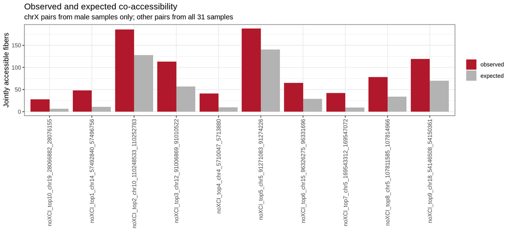

```r
if (nrow(selected_noxci)) {
  oe_noxci <- melt(selected_noxci[, .(pair_id, observed = co_access_noXCI,
                                      expected = expected_co_access_noXCI)],
                   id.vars = "pair_id", variable.name = "count_type", value.name = "fibers")
  oe_plot_noxci <- ggplot(oe_noxci, aes(pair_id, fibers, fill = count_type)) +
    geom_col(position = "dodge") + theme_bw() +
    scale_fill_manual(values = c(observed = "#B2182B", expected = "grey70")) +
    labs(x = NULL, y = "Jointly accessible fibers", fill = NULL,
         title = "Observed and expected co-accessibility",
         subtitle = "chrX pairs from male samples only; other pairs from all 31 samples") +
    theme(axis.text.x = element_text(angle = 90, hjust = 1, vjust = 0.5))
  print(oe_plot_noxci)
  ggsave(file.path(plot_dir_noxci, "LCL_top10_observed_expected_noXCI.pdf"), oe_plot_noxci,
         width = 11, height = 5)
}
```

### Genome-wide volcano of enriched pairs without chrx from females

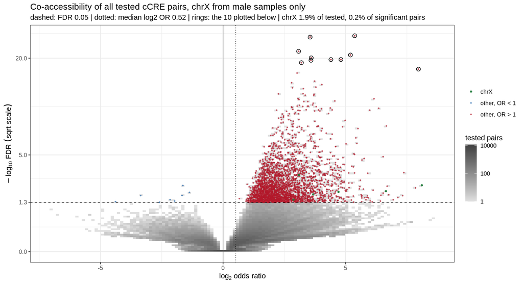

```r
volcano_noxci <- pairs_noxci[!is.na(fdr_noXCI) & is.finite(OR_noXCI) & OR_noXCI > 0, .(
  chrom,
  log2_OR = log2(OR_noXCI),
  neg_log10_fdr = -log10(pmax(fdr_noXCI, .Machine$double.xmin)),
  significant = fdr_noXCI < fdr_cutoff,
  direction = ifelse(OR_noXCI > 1, "co-accessible", "co-inaccessible"))]
volcano_noxci[, chrom_class := ifelse(chrom == "chrX", "chrX",
  ifelse(direction == "co-accessible", "other, OR > 1", "other, OR < 1"))]
median_log2_or_noxci <- median(volcano_noxci$log2_OR)
chosen_noxci <- selected_noxci[, .(log2_OR = log2(OR_noXCI),
  neg_log10_fdr = -log10(pmax(fdr_noXCI, .Machine$double.xmin)))]
signif_noxci <- volcano_noxci[significant == TRUE]

volcano_plot_noxci <- ggplot(volcano_noxci, aes(log2_OR, neg_log10_fdr)) +
  geom_bin2d(bins = 120) +
  scale_fill_gradient(low = "grey88", high = "grey25", trans = "log10",
                      name = "tested pairs") +
  geom_point(data = signif_noxci[chrom != "chrX"], aes(colour = chrom_class),
             size = 0.5, alpha = 0.6) +
  geom_point(data = signif_noxci[chrom == "chrX"], aes(colour = chrom_class),
             size = 0.9, alpha = 0.9) +
  scale_colour_manual(values = c("chrX" = "#1B7837", "other, OR > 1" = "#B2182B",
                                 "other, OR < 1" = "#2166AC"), name = NULL) +
  geom_point(data = chosen_noxci, shape = 21, size = 2.4, colour = "black", fill = NA,
             stroke = 0.6) +
  geom_vline(xintercept = 0, linewidth = 0.3, colour = "grey40") +
  geom_vline(xintercept = median_log2_or_noxci, linetype = "dotted", linewidth = 0.4) +
  geom_hline(yintercept = -log10(fdr_cutoff), linetype = "dashed", linewidth = 0.4) +
  scale_y_sqrt(breaks = c(0, 1.3, 5, 20, 50, 100)) +
  theme_bw(base_size = 11) +
  labs(x = expression(log[2]~odds~ratio), y = expression(-log[10]~FDR~(sqrt~scale)),
       title = "Co-accessibility of all tested cCRE pairs, chrX from male samples only",
       subtitle = sprintf(paste("dashed: FDR %.2f | dotted: median log2 OR %.2f |",
         "rings: the %d plotted below | chrX %.1f%% of tested, %.1f%% of significant pairs"),
         fdr_cutoff, median_log2_or_noxci, nrow(chosen_noxci),
         100 * mean(volcano_noxci$chrom == "chrX"),
         100 * mean(signif_noxci$chrom == "chrX")))
print(volcano_plot_noxci)
```

```r
ggsave(file.path(plot_dir_noxci, "LCL_coaccess_volcano_noXCI.pdf"), volcano_plot_noxci,
       width = 9, height = 6)
```

### single molecule view of top10 co-accessible regions with chrx removed from females

```r
pair_data_noxci <- list()
if (isTRUE(params$make_plots) && nrow(selected_noxci)) {
  for (i in seq_len(nrow(selected_noxci))) {
    pair <- selected_noxci[i]
    pair_samples <- if (pair$chrom == "chrX") male_samples_noxci else samples
    region <- list(chrom = pair$chrom, start = pair$region_start, end = pair$region_end)
    cre1 <- list(start = pair$cre1_start, end = pair$cre1_end)
    cre2 <- list(start = pair$cre2_start, end = pair$cre2_end)
    res <- load_region(region, pair_samples, paths$root, paths$fire_root,
      fire_ver = paths$fire_ver, tabix_bin = paths$tabix_bin,
      span_source = "aligned_blocks")
    labels <- label_reads(res, cre1, cre2, fire_overlap_fraction = fire_overlap_fraction)
    counts <- coaccess_2x2(labels)

    actual <- unlist(counts[1, c("neither", "cre1_only", "cre2_only", "both", "n_shared")],
                     use.names = FALSE)
    expected <- unlist(pair[, .(co_closed_noXCI, CRE1_access_noXCI, CRE2_access_noXCI,
                                co_access_noXCI, n_shared_reads_noXCI)], use.names = FALSE)
    if (!identical(as.numeric(actual), as.numeric(expected)))
      stop("Reloaded counts differ from the rebuilt table for ", pair$CRE_pair,
           "; reloaded: ", paste(actual, collapse = ","),
           "; rebuilt: ", paste(expected, collapse = ","))

    read_labels <- copy(labels)[shared == TRUE]
    read_labels[, donor := sample_meta$donor[match(sample_name, sample_meta$sample_name)]]
    read_labels[, `:=`(pair_id = pair$pair_id, CRE_pair = pair$CRE_pair)]
    fwrite(read_labels, file.path(table_dir_noxci,
      paste0(pair$pair_id, "_read_labels_noXCI.tsv.gz")), sep = "\t")
    contributions <- read_labels[, .(n_shared = .N, co_access = sum(acc1 & acc2),
      CRE1_access = sum(acc1 & !acc2), CRE2_access = sum(!acc1 & acc2),
      co_closed = sum(!acc1 & !acc2)), by = .(pair_id, sample_name, donor)]
    fwrite(contributions, file.path(table_dir_noxci,
      paste0(pair$pair_id, "_sample_counts_noXCI.tsv")), sep = "\t")

    pair_data_noxci[[pair$pair_id]] <- list(pair = pair, region = region,
      cre1 = cre1, cre2 = cre2, res = res, labels = labels, counts = counts)
  }
}
```

```r
fiber_plots_noxci <- list()
fig_heights_noxci <- c()
for (id in names(pair_data_noxci)) {
  entry <- pair_data_noxci[[id]]
  pair <- entry$pair
  region <- entry$region
  counts <- entry$counts

  # window-spanning shared fibers, co-accessible first, capped at max_drawn
  spanning <- entry$res$spans[start <= region$start & end >= region$end, key]
  drawn_labels <- copy(entry$labels)[shared == TRUE & key %in% spanning]
  setorder(drawn_labels, config)
  n_spanning <- nrow(drawn_labels)
  if (n_spanning > max_drawn) drawn_labels <- drawn_labels[seq_len(max_drawn)]

  display_res <- load_ft_tracks(copy(entry$res), keys = drawn_labels$key,
    ft_root = paths$ft_root, tabix_bin = paths$tabix_bin,
    nuc_source = "ft", tf_source = "recalled_tf", tf_root = paths$tf_root)
  for (track in c("spans", "blocks", "elements", "m6a", "nuc", "size_fps")) {
    if (!is.null(display_res[[track]]) && nrow(display_res[[track]]))
      display_res[[track]][, sample_name := "pooled"]
  }
  display_res$samples <- "pooled"
  drawn_labels[, sample_name := "pooled"]

  cres_here <- cre_universe[chrom == region$chrom & end > region$start & start < region$end]
  region_res <- coaccess_region_result(display_res, entry$cre1, entry$cre2,
    drawn_labels, cres = cres_here)
  # co-accessible fibers on top, in both rasters
  rid_levels <- rev(levels(region_res$rids_df$RID))
  for (tb in c("reads", "rids_df", "fire", "nucs", "fps", "fps_infire")) {
    if (!is.null(region_res[[tb]]) && nrow(region_res[[tb]]))
      region_res[[tb]][["RID"]] <- factor(as.character(region_res[[tb]][["RID"]]),
                                          levels = rid_levels)
  }
  pk <- as.data.frame(cres_here)
  cls <- factor(pk$CRE_label, levels = c(intersect(CCRE_CLASSES, pk$CRE_label),
    setdiff(unique(pk$CRE_label), CCRE_CLASSES)))
  pk <- pk[order(cls, pk$start), , drop = FALSE]
  peaks_df <- data.frame(chr = pk$chrom, start = pk$start, end = pk$end,
    group = as.character(pk$CRE_label))

  subtitle <- sprintf("%s:%d-%d | %s", region$chrom, region$start, region$end,
    if (pair$chrom == "chrX") sprintf("chrX: %d male samples", length(male_samples_noxci))
    else sprintf("all %d samples", length(samples)))
  subtitle <- paste0(subtitle, "\n", sprintf(paste0(
    "%d fibers fully cover both cCREs: both %d | CRE1 only %d | CRE2 only %d | neither %d",
    " | Fisher OR (table + 1) = %.2f, p = %.2g"), counts$n_shared,
    counts$both, counts$cre1_only, counts$cre2_only, counts$neither,
    counts$fisher_or, counts$fisher_p))

  raster_height <- max(2, 0.025 * nrow(drawn_labels) + 0.3)
  heights <- c(pileup = 1.5, peaks = 0.3 + 0.3 * length(unique(peaks_df$group)),
    reads = raster_height, fire_fiberHMM = raster_height)
  read_theme <- list(axis.ticks.y = element_blank(), panel.grid.major.y = element_blank())
  fiber_plots_noxci[[id]] <- plot_region_panels(region_res,
    plot_name = paste(id, pair$gene_names, pair$CRE_pair_labels,
      sprintf("%d of %d window-spanning fibers drawn, co-accessible first",
              nrow(drawn_labels), n_spanning), sep = " | "),
    subtitle = subtitle, peaks_df = peaks_df, highlight = region_res$highlight,
    linewidth = 1.1, expand = TRUE, heights = heights,
    profile_options = list(colour_by = "group", colors = cluster_palette("pooled"),
      y_col = "frac", linewidth = 0.4, facet_scales = "fixed",
      facet_space = "fixed", require_data = TRUE),
    read_options = list(tile_width = 8, tile_height = 0.85,
      backbone_col = BACKBONE_COL, arrows = FALSE,
      base_colors = c(A = M6A_COL), require_data = TRUE),
    peaks_options = list(variant = "intervals"),
    footprint_options = list(draw_order = c("linker", "nucleosome", "FIRE element",
      rev(region_res$size_levels)), backbone = FALSE, always = TRUE,
      legend_title = NULL, legend_drop = FALSE, legend_linewidth = 3),
    theme_options = list(base = "bw", base_size = 11,
      pileup = list(strip.text.y = element_text(angle = 0)),
      reads = read_theme, fire_fiberHMM = read_theme),
    y_labels = c(pileup = "m6A fraction", reads = "m6A",
      fire_fiberHMM = "ft nucleosomes + FIRE + FiberHMM TF"),
    panel_names = c(peaks = "cres", pileup = "m6a_prop", reads = "m6a", fire_fiberHMM = "reads"))
  fig_heights_noxci[id] <- 6 + 0.05 * nrow(drawn_labels)
  ggsave(file.path(plot_dir_noxci, paste0(id, "_reads_noXCI.pdf")),
    fiber_plots_noxci[[id]]$combined, width = 12, height = fig_heights_noxci[[id]],
    limitsize = FALSE)
}
```

```r
if (length(pair_data_noxci)) {
  show_region_figures(fiber_plots_noxci, heights = fig_heights_noxci,
    titles = sapply(names(pair_data_noxci), function(id)
      paste0(id, ": ", pair_data_noxci[[id]]$pair$gene_names)),
    fig_dir = plot_dir_noxci, header = "###", label_prefix = "noxci-fiber-")
} else {
  cat("No fiber plots requested or no qualifying pairs.\n")
}
```

### noXCI_top1_chr14_57492840_57496756: CCDC198

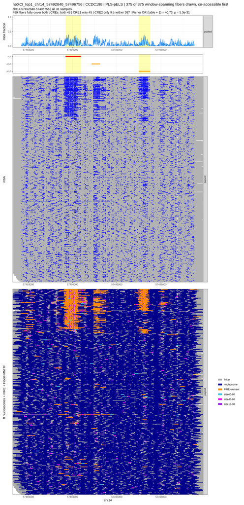

### noXCI_top2_chr10_110248533_110252783: ENSG00000214067

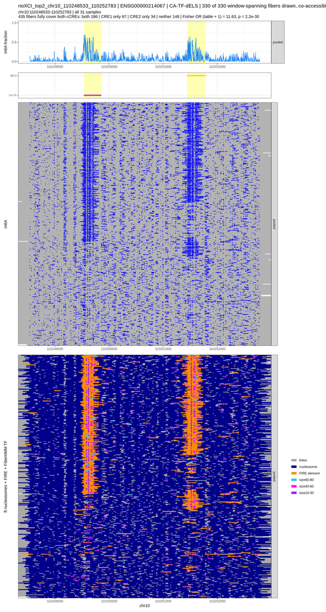

### noXCI_top3_chr12_91006869_91010522: EPYC

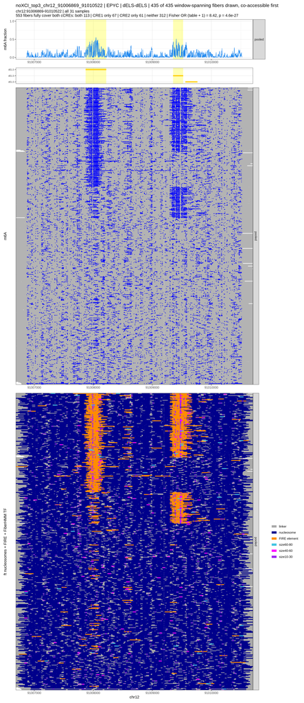

### noXCI_top4_chr4_5710047_5713880: EVC;EVC2

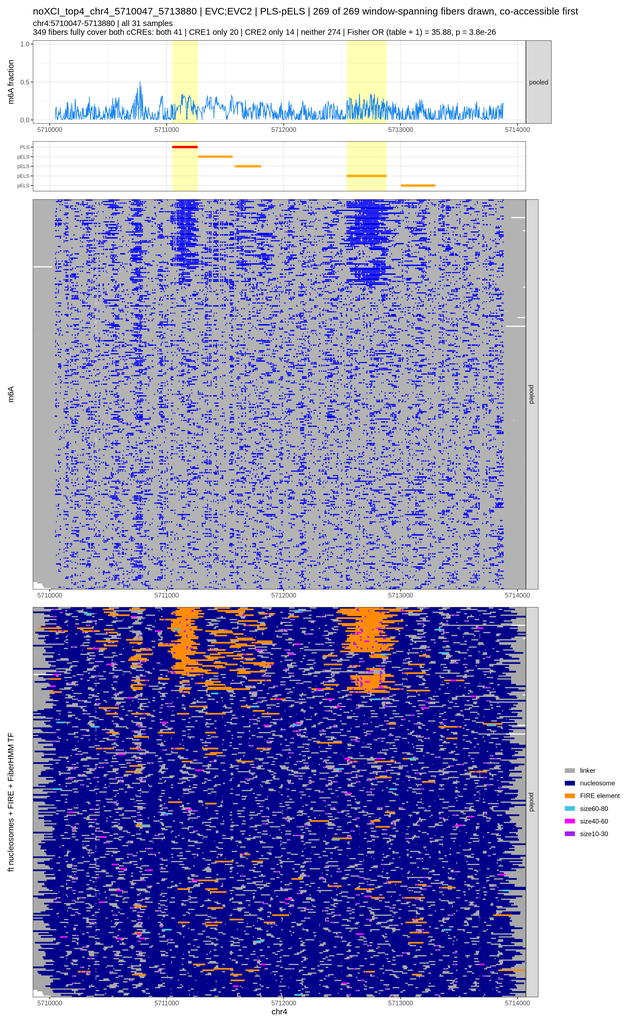

### noXCI_top5_chr5_91271083_91274226: ENSG00000234292;ENSG00000286638;RNU4-90P

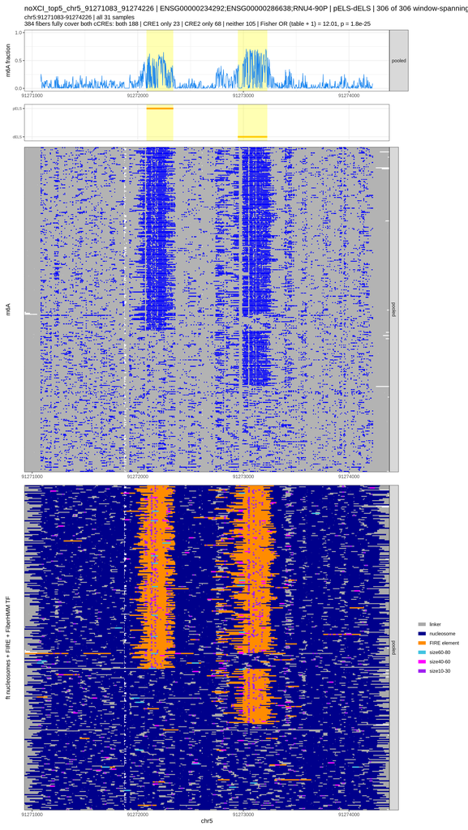

### noXCI_top6_chr15_96326275_96331696: MIR1469;NR2F2;NR2F2-AS1

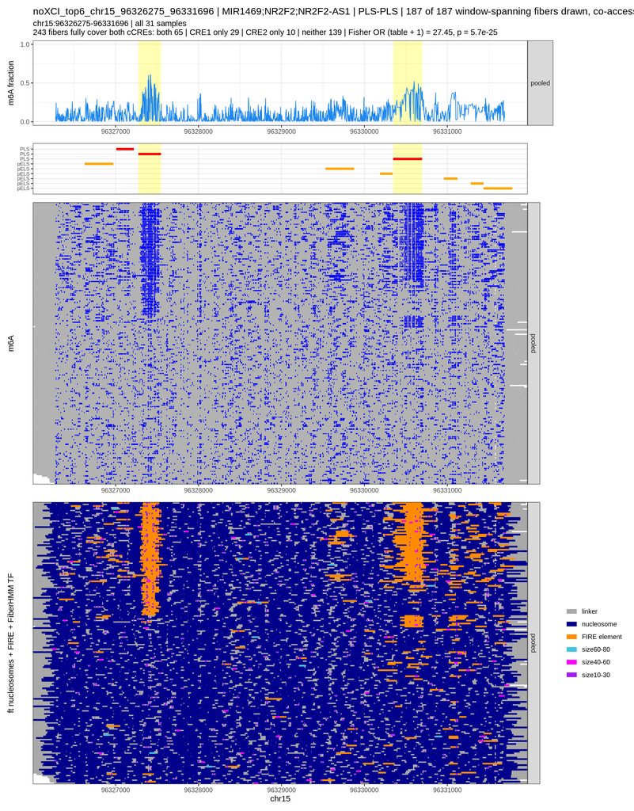

### noXCI_top7_chr5_169543312_169547072: RNU6-477P

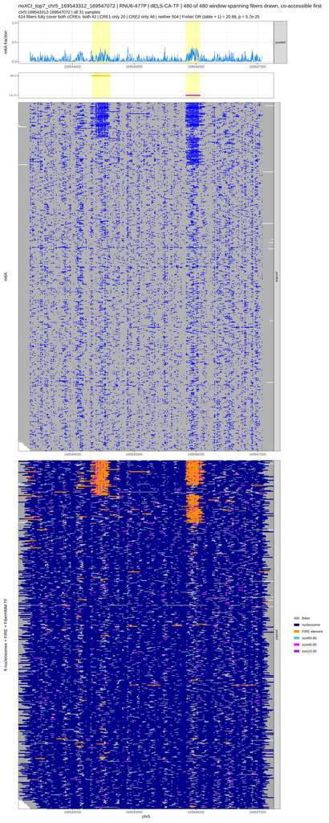

### noXCI_top8_chr5_107811585_107814966: RN7SKP122

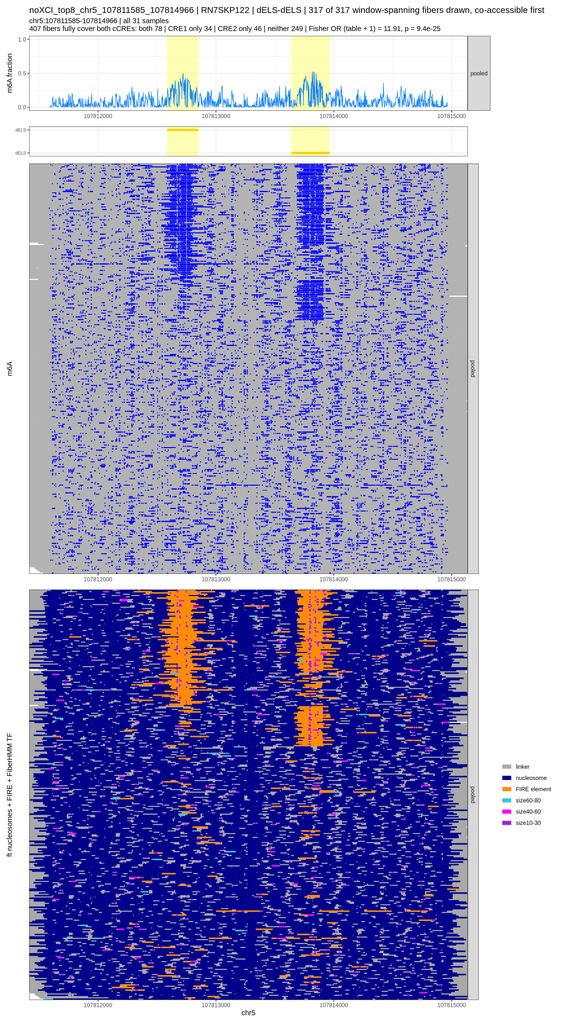

### noXCI_top9_chr18_54146508_54150361: ENSG00000264296

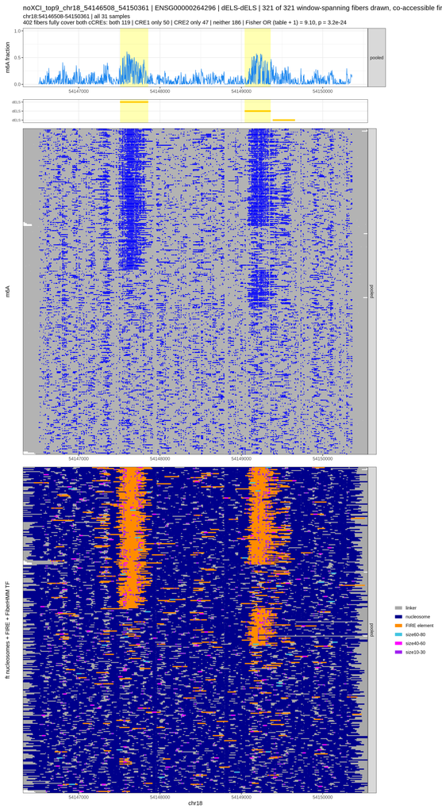

### noXCI_top10_chr19_28066882_28076155: ENSG00000267509

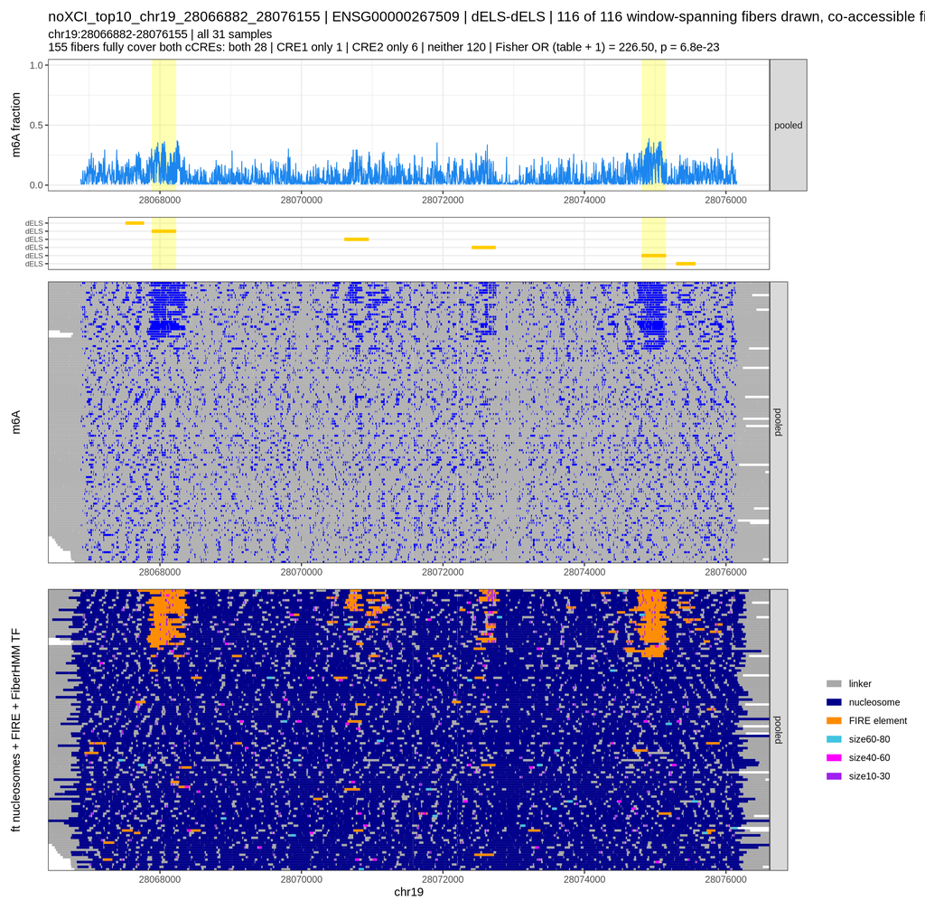

### top 5 co-accessible pairs ranked by # of co-accessible fibers

same filters as the top 10 without female chrx: fdr < 0.05, OR > 1, observed co-accessibility > expected

highest # of co-accessible fibers -> smallest FDR -> largest OR -> highest # of spanning molecules -> pair ID alphabetical order

```r
top5_noxci <- copy(eligible_noxci)
setorderv(top5_noxci, c("co_access_noXCI", "fdr_noXCI", "OR_noXCI", "n_shared_reads_noXCI", "CRE_pair"),
          c(-1L, 1L, -1L, -1L, 1L))
top5_noxci <- head(top5_noxci, 5L)
top5_noxci[, `:=`(
  region_start = pmax(0L, pmin(cre1_start, cre2_start) - as.integer(params$locus_flank_bp)),
  region_end = pmax(cre1_end, cre2_end) + as.integer(params$locus_flank_bp))]
top5_noxci[, pair_id := sprintf("noXCI_coaccess_top%d_%s_%d_%d", seq_len(.N), chrom,
                                region_start, region_end)]
fwrite(top5_noxci, file.path(table_dir_noxci, "LCL_top5_coaccess_pairs_noXCI.tsv"), sep = "\t")

head(top5_noxci[, .(pair_id, gene_names, CRE_pair, n_shared_reads_noXCI, co_access_noXCI,
  expected_co_access_noXCI, observed_expected_ratio_noXCI, OR_noXCI, fdr_noXCI)])
```

```
##                                        pair_id                   gene_names
##                                         <char>                       <char>
## 1: noXCI_coaccess_top1_chr14_89953681_89957083 EFCAB11;ENSG00000259053;TDP1
## 2:  noXCI_coaccess_top2_chr2_99335265_99338515                 EIF5B;TXNDC9
## 3:  noXCI_coaccess_top3_chr6_83064688_83068796                  DOP1A;UBE3D
## 4:  noXCI_coaccess_top4_chr3_61248997_61252690                         FHIT
## 5:  noXCI_coaccess_top5_chr7_66994484_66997909                    SBDS;TYW1
##                                                        CRE_pair
##                                                          <char>
## 1:  EH38D4837202.EH38E3110103.PLS-EH38D2749750.EH38E1735117.PLS
## 2:  EH38D3155138.EH38E2018278.PLS-EH38D3155140.EH38E2018280.PLS
## 3:  EH38D5771362.EH38E3718710.PLS-EH38D5771365.EH38E3718712.PLS
## 4: EH38D5460176.EH38E3518708.pELS-EH38D5460178.EH38E3518710.PLS
## 5:  EH38D5860698.EH38E3777333.PLS-EH38D5860700.EH38E3777335.PLS
##    n_shared_reads_noXCI co_access_noXCI expected_co_access_noXCI
##                   <int>           <int>                    <num>
## 1:                  433             385                 371.1778
## 2:                  438             374                 364.9110
## 3:                  457             367                 358.4902
## 4:                  412             364                 358.8350
## 5:                  361             342                 336.3490
##    observed_expected_ratio_noXCI  OR_noXCI          fdr_noXCI
##                            <num>     <num>              <num>
## 1:                      1.037239 31.548077 0.0000000006142032
## 2:                      1.024908  8.705357 0.0005428278155099
## 3:                      1.023738  5.366667 0.0084934994768989
## 4:                      1.014394  6.320346 0.0404527242077325
## 5:                      1.016801 92.346154 0.0000149530664590
```

```r
fiber_plots_top5 <- list()
fig_heights_top5 <- c()
if (isTRUE(params$make_plots) && nrow(top5_noxci)) {
  for (i in seq_len(nrow(top5_noxci))) {
    pair <- top5_noxci[i]
    id <- pair$pair_id
    pair_samples <- if (pair$chrom == "chrX") male_samples_noxci else samples
    region <- list(chrom = pair$chrom, start = pair$region_start, end = pair$region_end)
    cre1 <- list(start = pair$cre1_start, end = pair$cre1_end)
    cre2 <- list(start = pair$cre2_start, end = pair$cre2_end)
    res <- load_region(region, pair_samples, paths$root, paths$fire_root,
      fire_ver = paths$fire_ver, tabix_bin = paths$tabix_bin,
      span_source = "aligned_blocks")
    labels <- label_reads(res, cre1, cre2, fire_overlap_fraction = fire_overlap_fraction)
    counts <- coaccess_2x2(labels)

    # window-spanning shared fibers, co-accessible first, capped at max_drawn
    spanning <- res$spans[start <= region$start & end >= region$end, key]
    drawn_labels <- copy(labels)[shared == TRUE & key %in% spanning]
    setorder(drawn_labels, config)
    n_spanning <- nrow(drawn_labels)
    if (n_spanning > max_drawn) drawn_labels <- drawn_labels[seq_len(max_drawn)]

    display_res <- load_ft_tracks(copy(res), keys = drawn_labels$key,
      ft_root = paths$ft_root, tabix_bin = paths$tabix_bin,
      nuc_source = "ft", tf_source = "recalled_tf", tf_root = paths$tf_root)
    for (track in c("spans", "blocks", "elements", "m6a", "nuc", "size_fps")) {
      if (!is.null(display_res[[track]]) && nrow(display_res[[track]]))
        display_res[[track]][, sample_name := "pooled"]
    }
    display_res$samples <- "pooled"
    drawn_labels[, sample_name := "pooled"]

    cres_here <- cre_universe[chrom == region$chrom & end > region$start & start < region$end]
    region_res <- coaccess_region_result(display_res, cre1, cre2,
      drawn_labels, cres = cres_here)
    # co-accessible fibers on top, in both rasters
    rid_levels <- rev(levels(region_res$rids_df$RID))
    for (tb in c("reads", "rids_df", "fire", "nucs", "fps", "fps_infire")) {
      if (!is.null(region_res[[tb]]) && nrow(region_res[[tb]]))
        region_res[[tb]][["RID"]] <- factor(as.character(region_res[[tb]][["RID"]]),
                                            levels = rid_levels)
    }
    pk <- as.data.frame(cres_here)
    cls <- factor(pk$CRE_label, levels = c(intersect(CCRE_CLASSES, pk$CRE_label),
      setdiff(unique(pk$CRE_label), CCRE_CLASSES)))
    pk <- pk[order(cls, pk$start), , drop = FALSE]
    peaks_df <- data.frame(chr = pk$chrom, start = pk$start, end = pk$end,
      group = as.character(pk$CRE_label))

    subtitle <- sprintf("%s:%d-%d | %s", region$chrom, region$start, region$end,
      if (pair$chrom == "chrX") sprintf("chrX: %d male samples", length(male_samples_noxci))
      else sprintf("all %d samples", length(samples)))
    subtitle <- paste0(subtitle, "\n", sprintf(paste0(
      "%d fibers fully cover both cCREs: both %d | CRE1 only %d | CRE2 only %d | neither %d",
      " | Fisher OR (table + 1) = %.2f, p = %.2g"), counts$n_shared,
      counts$both, counts$cre1_only, counts$cre2_only, counts$neither,
      counts$fisher_or, counts$fisher_p))

    raster_height <- max(2, 0.025 * nrow(drawn_labels) + 0.3)
    heights <- c(pileup = 1.5, peaks = 0.3 + 0.3 * length(unique(peaks_df$group)),
      reads = raster_height, fire_fiberHMM = raster_height)
    read_theme <- list(axis.ticks.y = element_blank(), panel.grid.major.y = element_blank())
    fiber_plots_top5[[id]] <- plot_region_panels(region_res,
      plot_name = paste(id, pair$gene_names, pair$CRE_pair_labels,
        sprintf("%d of %d window-spanning fibers drawn, co-accessible first",
                nrow(drawn_labels), n_spanning), sep = " | "),
      subtitle = subtitle, peaks_df = peaks_df, highlight = region_res$highlight,
      linewidth = 1.1, expand = TRUE, heights = heights,
      profile_options = list(colour_by = "group", colors = cluster_palette("pooled"),
        y_col = "frac", linewidth = 0.4, facet_scales = "fixed",
        facet_space = "fixed", require_data = TRUE),
      read_options = list(tile_width = 8, tile_height = 0.85,
        backbone_col = BACKBONE_COL, arrows = FALSE,
        base_colors = c(A = M6A_COL), require_data = TRUE),
      peaks_options = list(variant = "intervals"),
      footprint_options = list(draw_order = c("linker", "nucleosome", "FIRE element",
        rev(region_res$size_levels)), backbone = FALSE, always = TRUE,
        legend_title = NULL, legend_drop = FALSE, legend_linewidth = 3),
      theme_options = list(base = "bw", base_size = 11,
        pileup = list(strip.text.y = element_text(angle = 0)),
        reads = read_theme, fire_fiberHMM = read_theme),
      y_labels = c(pileup = "m6A fraction", reads = "m6A",
        fire_fiberHMM = "ft nucleosomes + FIRE + FiberHMM TF"),
      panel_names = c(peaks = "cres", pileup = "m6a_prop", reads = "m6a", fire_fiberHMM = "reads"))
    fig_heights_top5[id] <- 6 + 0.05 * nrow(drawn_labels)
    ggsave(file.path(plot_dir_noxci, paste0(id, "_reads_noXCI.pdf")),
      fiber_plots_top5[[id]]$combined, width = 12, height = fig_heights_top5[[id]],
      limitsize = FALSE)
  }
}
```

```r
if (length(fiber_plots_top5)) {
  show_region_figures(fiber_plots_top5, heights = fig_heights_top5,
    titles = setNames(paste0(top5_noxci$pair_id, ": ", top5_noxci$gene_names), top5_noxci$pair_id),
    fig_dir = plot_dir_noxci, header = "####")
} else {
  cat("No fiber plots requested or no qualifying pairs.\n")
}
```

#### noXCI_coaccess_top1_chr14_89953681_89957083: EFCAB11;ENSG00000259053;TDP1

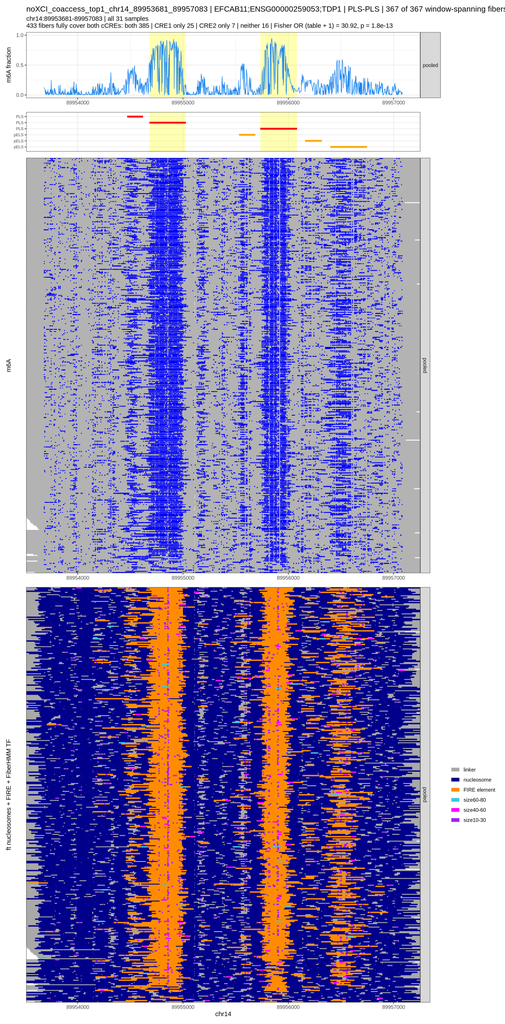

#### noXCI_coaccess_top2_chr2_99335265_99338515: EIF5B;TXNDC9

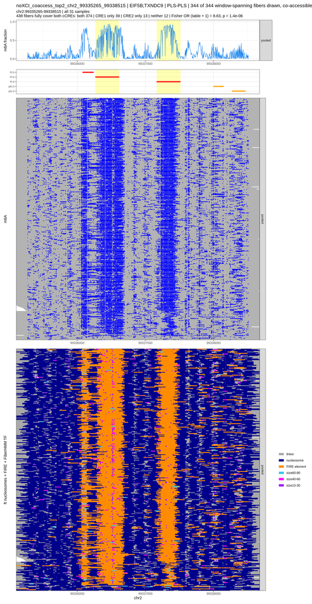

#### noXCI_coaccess_top3_chr6_83064688_83068796: DOP1A;UBE3D

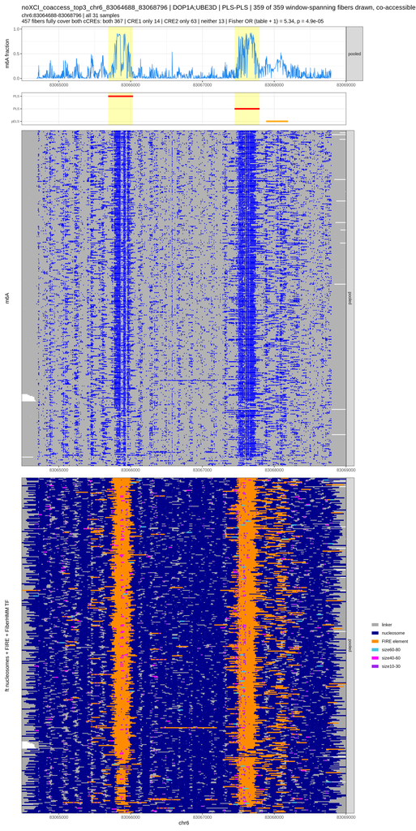

#### noXCI_coaccess_top4_chr3_61248997_61252690: FHIT

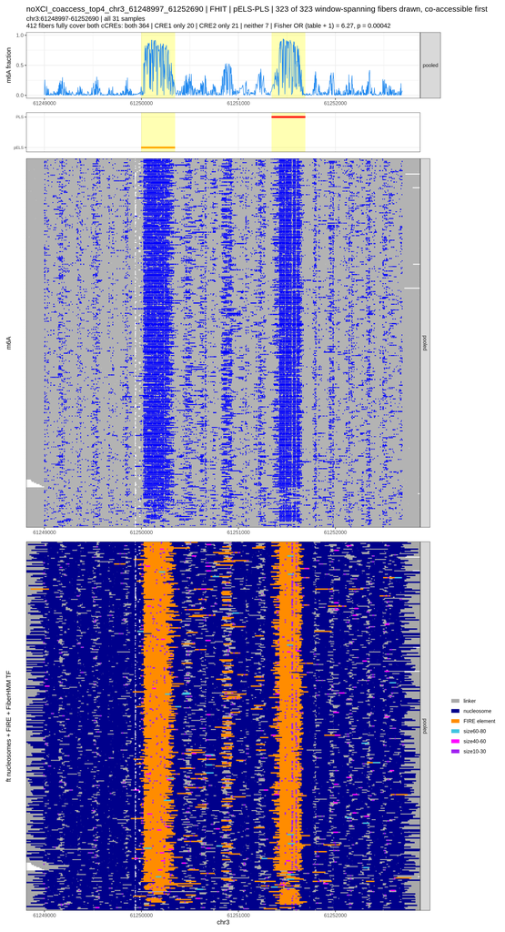

#### noXCI_coaccess_top5_chr7_66994484_66997909: SBDS;TYW1

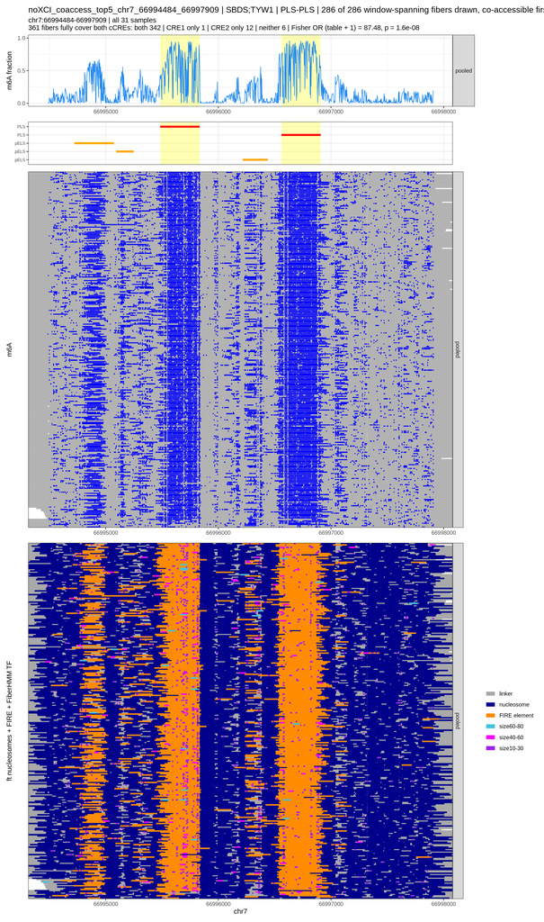